# Observational Data – Management Outcomes

Mike Verhoeven

2022-09-30

This script will examine the effects of control targeting invaders on both the invaders and the native plant community.

## Document Preamble

```r
# load libraries ------------------------------------------------------------------
# # Load Libraries
library(data.table)
update_dev_pkg()# remotes::install_github("Rdatatable/data.table")
```

```
## R data.table package is up-to-date at c4a2085e35689a108d67dacb2f8261e4964d7e12 (1.14.3)
```

```r
# library(ggplot2)
library(stringr)
# library(sf)
# library(vegan)
# library(gridExtra)
# library(dplyr)
library(tidyr)
library(lme4)
library(sjPlot)
library(mediation)
library(ggpubr)
library(EnvStats)
library(lmerTest)
library(merTools)
library(rstanarm)
library(janitor)
library(MatchIt)
library(optmatch)
library("lmtest") #coeftest
library("sandwich") #vcovCL


# library(maps)
# library(rgdal)
# library(ggsn)
# library(moments)
# library(shiny)
# library(plotly)
# library(ggspatial)
# library(broom)
# library(woodson)
#



# load in functions -------------------------------------------------------

# ben bolkers CI calc fn (https://github.com/bbolker/asaglmm/blob/master/papers/bolker_chap.rmd)
easyPredCIbinom <- function(model,newdata,alpha=0.05) {
  ## baseline prediction, on the linear predictor (log-odds) scale:
  pred0 <- predict(model,re.form=NA,newdata=newdata)
  ## fixed-effects model matrix for new data
  X <- model.matrix(formula(model,fixed.only=TRUE)[-2],
                    newdata)
  beta <- fixef(model) ## fixed-effects coefficients
  V <- vcov(model)     ## variance-covariance matrix of beta
  pred.se <- sqrt(diag(X %*% V %*% t(X))) ## std errors of predictions
  ## inverse-link (logistic) function: could also use plogis()
  plogis <- model@resp$family$plogis
  ## construct 95% Normal CIs on the link scale and
  ##  transform back to the response (probability) scale:
  crit <- -qnorm(alpha/2)
  plogis(cbind(lwr=pred0-crit*pred.se,
               upr=pred0+crit*pred.se))
}



# load in data -------------------------------------------------
#
plants <- fread(file = "data&scripts/data/output/plants_env_data.csv", drop = 1)
plants_occurrence_wide <- fread(file = "data&scripts/data/output/plants_env_data_wide.csv", drop = 1)
plants_rakeabund_wide <- fread(file = "data&scripts/data/output/plants_abund_env_data_wide.csv")
surveys <- fread(file = "data&scripts/data/output/surveys_aqplants.csv")

load("synthesis_script_datasets.Rdata")

#management data
# source(file = "data&scripts/c1_management_outcomes.R") # will load and clean management data and leave in WS a mgmtdata file

surveys_mgmt <- fread( file = "data&scripts/data/output/survs_mgmt_dateprelabelled.csv")

#other covariates?
#shyams EWM proj Data?:
# here we have depth, GDD, others
b <- fread('https://github.com/ShyamThomas/Watermilfoil_RF_SDMs/raw/master/Data/EWMlakeindex.allwatchem.NLDASwtmp2.csv')
# here we have road density w/in 500m buffer
c <- fread(file = "data&scripts/data/input/Lakes_RoadDensity.csv")
```

# Issues to address:

## Invader p/a and abundance metrics:

Because of the distinct phenology of CLP, we’ve got to use estimates of abundance from early season surveys (during the growth phase of CLP annual life cycle).

We can do this ONLY for the survey level work… That’s b/c at the point level we don’t have the ability to connect two sample locations across time.

So at the lake scale, we will use spring (Mar-June) surveys to come up with a value for CLP abundance and we can link this by lake over to the summer native community surveys. In line with this, we’ll have a bunch of NA values for spring CLP abundance– these are surveys that have no springtime pair that could reasonably be considered an assesment of CLP.

At the point scale we need to use the point-level abundance data. Do we just use all data (and model date as a driving factor)? Just summer?

## Space for time?

We’ve got a pile of data, but its a messy pile. We’ve got lots of repeat sampling, but it’s not consistent and there are lots of holes. The way we treated this previously was to run models with lake ID as a random effect. We can try that again here, or we might consider other options.

## Pre or post treatment for each survey

Because we have (at best) a fuzzy idea of the dates of treatments, I have manually reviewed each survey with a treatment in that year (~350) and based on all the reported mgmt dates I designated each survey as pre- or post- treatment.

## “Managed”

We have a somewhat poor idea of which lakes received management to control EWM or CLP in MN. We’ve got a dataset that does our best to assess this question. My gut feeling (and nothing more than that) tells me we’ve probably got 80% of the CLP & EWM management efforts captured in our dataset.

Then there’s the question of what it means to be “managed.” You might have managed the entire pop extent in your lake–or maybe you just managed 5% of the pop extent because you didn’t have the money. Maybe you chose to use an herbicide control approach that used repeated herbicide in the same areas (EWM). Or maybe you’ve used some combination of herb and mechanical control. Did you control every other year? Every year? Why?

We’ve got a tiered set of metrics that move from least precise about control (this lake-year was managed for AN invader), to most precise (this lake-year was managed for this invader on this date on X acres–at this point I have not included method, but could if we dream up a clean way to do that)

## Effects of Management

As we showed with the CLP paper, the temporal frame at which we ask if there was an “effect” of management is not straightforward. Previously we asked about a w/in year effect, a following year effect, and an effect of cumulative yrs of trt.

To-date we have not coded the data this way. Instead, we create a set of management indices. We’ve got a set of metrics that start with: sum(1 / (current year - management year + 1)) eg: for 2019 survey with 2017 and 2015 management, mgmt index = sum( 1/3 + 1/5)

then I carry this same concept through to acreage, except there we assign the numerator as acres in management year. # Data Prep:

```r
#clean up the management data: (assign zeros or NAs as appropriate)

names(surveys_mgmt)
```

```
##   [1] "ewm_pretrt"                     "clp_pretrt"
##   [3] "DOW"                            "lakename"
##   [5] "year"                           "DATESURVEYSTART"
##   [7] "date1"                          "date2"
##   [9] "date3"                          "date4"
##  [11] "date5"                          "date6"
##  [13] "date7"                          "date8"
##  [15] "date9"                          "p_dow"
##  [17] "SUBBASIN"                       "i.lakename"
##  [19] "clp_ntrtdates"                  "clp_m"
##  [21] "i.p_dow"                        "i.lakename.2"
##  [23] "ewm_ntrtdates"                  "ewm_m"
##  [25] "i.p_dow.2"                      "i.lakename.1"
##  [27] "ntrtdates"                      "m"
##  [29] "i.p_dow.1"                      "fw_id"
```

[output cut: 159 more lines]

```r
#pre- or post- treatment survey timing
surveys_mgmt[!is.na(ewm_ntrtdates) & (ewm_ntrtdates>0) & is.na(ewm_pretrt)    , ewm_pretrt := 0 ,]
surveys_mgmt[!is.na(clp_ntrtdates) & (clp_ntrtdates>0) & is.na(clp_pretrt)    , clp_pretrt := 0 ,]
surveys_mgmt[(clp_ntrtdates == 0)    , clp_pretrt := NA ,]

#lakename from mgmt dat can be dropped:
surveys_mgmt[ , c("lakename","i.lakename","i.lakename.2","i.lakename.1") := NULL]

# mash mgmtdates:
surveys_mgmt[ , mgmtdates:= paste(date1,date2,date3,date4,date5,date6,date7,date8,date9) , ]
surveys_mgmt[, c("date1","date2","date3","date4","date5","date6","date7","date8","date9") := NULL ]

#dump parent dows
surveys_mgmt[ , c("p_dow","i.p_dow","i.p_dow.2","i.p_dow.1") := NULL , ]

#species targeted dates & acres:
surveys_mgmt[ , .N , clp_ntrtdates]
```

```
##    clp_ntrtdates     N
##            <int> <int>
## 1:             1   162
## 2:             0   213
## 3:            NA  2785
## 4:             2    10
## 5:             4     1
## 6:             3     4
```

```r
surveys_mgmt[ , .N , ewm_ntrtdates]
```

```
##    ewm_ntrtdates     N
##            <int> <int>
## 1:             1   102
## 2:             0   271
## 3:             3     1
## 4:            NA  2785
## 5:             2    14
## 6:             4     2
```

```r
surveys_mgmt[ , summary(clp_m) , ]
```

```
##    Min. 1st Qu.  Median    Mean 3rd Qu.    Max.    NA's
##  0.0000  0.0000  0.7500  0.7868  1.5000  2.5929    2785
```

```r
surveys_mgmt[ , summary(ewm_m) , ]
```

```
##    Min. 1st Qu.  Median    Mean 3rd Qu.    Max.    NA's
##  0.0000  0.0000  0.0000  0.5387  1.0000  2.5929    2785
```

```r
surveys_mgmt[ , summary(clp_controlacres) , ]
```

```
##    Min. 1st Qu.  Median    Mean 3rd Qu.    Max.    NA's
##     0.0     0.0     0.0    27.3    30.0   600.0    2889
```

```r
surveys_mgmt[ , summary(ewm_controlacres) , ]
```

```
##    Min. 1st Qu.  Median    Mean 3rd Qu.    Max.    NA's
##   0.000   0.000   0.000   6.044   4.628  96.600    2865
```

```r
surveys_mgmt[ , summary(clp_acres_m) , ]
```

```
##    Min. 1st Qu.  Median    Mean 3rd Qu.    Max.    NA's
##    0.00    0.00   12.44   45.20   46.65 1103.33    2865
```

```r
surveys_mgmt[ , summary(ewm_acres_m) , ]
```

```
##    Min. 1st Qu.  Median    Mean 3rd Qu.    Max.    NA's
##    0.00    0.00    0.00   12.11   13.80  215.18    2865
```

```r
surveys_mgmt[ , .N , ntrtdates]
```

```
##    ntrtdates     N
##        <int> <int>
## 1:         1   136
## 2:         2   108
## 3:         0   148
## 4:        NA  2755
## 5:         3    14
## 6:         4    10
## 7:         5     3
## 8:         6     1
```

```r
surveys_mgmt[ , summary(m) , ]
```

```
##    Min. 1st Qu.  Median    Mean 3rd Qu.    Max.
##  0.0000  0.0000  0.0000  0.1444  0.0000  2.5929
```

```r
surveys <- surveys_mgmt
rm(surveys_mgmt)
```

for many of these, we will be leaving the NA values in. There may be a reason to do this to reflect a lack of info on a givene lake/yr (0 treatment implies something different from, “we didn’t find any record of it”)

#’ Recall seasonality of surveys is important re: phenology of clp

```r
# add a CLP metric to summer surveys where CLP was measured during a reasonable time of year --------

surveys[ , DATESURVEYSTART := as.IDate(DATESURVEYSTART, format = "%m/%d/%Y" ) , ]

#put a CLP index into the summer surveys:
early_clpsurveys <- surveys[month(DATESURVEYSTART) %in% c(3,4,5,6) , .(SURVEY_ID, DOW, year = year(DATESURVEYSTART), LAKE_NAME, SUBBASIN, Potamogeton_crispus,DATESURVEYSTART, n_points_vegetated, tot_n_samp)  , ]

early_clpsurveys[ , potcri_early_vegdfoc := Potamogeton_crispus/n_points_vegetated ]
early_clpsurveys[is.na(potcri_early_vegdfoc), potcri_early_vegdfoc := 0] #here we can assume that the sampling was reasonable timing to find CLP had it been present
early_clpsurveys[ ,.N , potcri_early_vegdfoc>0]
```

```
##    potcri_early_vegdfoc     N
##                  <lgcl> <int>
## 1:                 TRUE   669
## 2:                FALSE   452
```

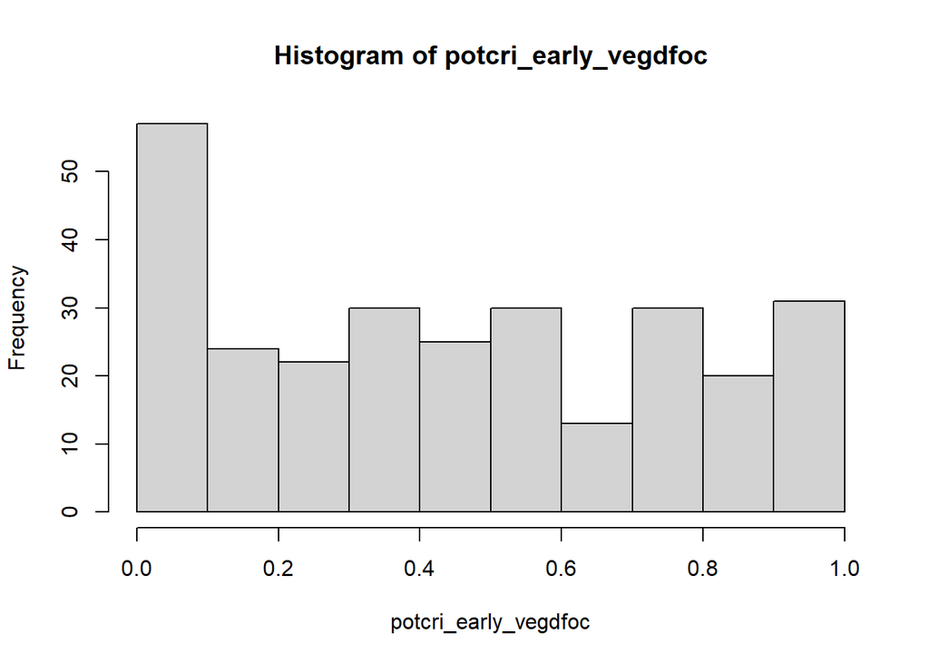

```
## $breaks
##  [1] 0.0 0.1 0.2 0.3 0.4 0.5 0.6 0.7 0.8 0.9 1.0
##
## $counts
##  [1] 57 24 22 30 25 30 13 30 20 31
##
## $density
##  [1] 2.0212766 0.8510638 0.7801418 1.0638298 0.8865248 1.0638298 0.4609929
##  [8] 1.0638298 0.7092199 1.0992908
##
## $mids
##  [1] 0.05 0.15 0.25 0.35 0.45 0.55 0.65 0.75 0.85 0.95
##
## $xname
## [1] "potcri_early_vegdfoc"
##
## $equidist
## [1] TRUE
##
## attr(,"class")
## [1] "histogram"
```

```r
surveys[ , year := year(DATESURVEYSTART) , ]

#thin summer surveys to exclude pre july
summer_surveys <- surveys[yday(DATESURVEYSTART) > 181  , , ]

#append early clp metrics to these summer surveys,:

summer_surveys[ , joindates := DATESURVEYSTART]
early_clpsurveys[ , joindateE := DATESURVEYSTART]


summer_surveys <- early_clpsurveys[summer_surveys, on = .(DOW, year, LAKE_NAME, SUBBASIN, joindateE < joindates), mult = "first" ]

names(summer_surveys)[names(summer_surveys) == "DATESURVEYSTART"] <- "SPRING_DATESURVEYSTART"
names(summer_surveys)[names(summer_surveys) == "SURVEY_ID"] <- "SPRING_SURVEY_ID"
names(summer_surveys)[names(summer_surveys) == "Potamogeton_crispus"] <- "SPRING_Potamogeton_crispus"
names(summer_surveys)[names(summer_surveys) == "n_points_vegetated"] <- "SPRING_n_points_vegetated"
names(summer_surveys)[names(summer_surveys) == "tot_n_samp"] <- "SPRING_tot_n_samp"

names(summer_surveys)[names(summer_surveys) == "i.DATESURVEYSTART"] <- "DATESURVEYSTART"
names(summer_surveys)[names(summer_surveys) == "i.SURVEY_ID"] <- "SURVEY_ID"
names(summer_surveys)[names(summer_surveys) == "i.Potamogeton_crispus"] <- "Potamogeton_crispus"
names(summer_surveys)[names(summer_surveys) == "i.n_points_vegetated"] <- "n_points_vegetated"
names(summer_surveys)[names(summer_surveys) == "i.tot_n_samp"] <- "tot_n_samp"



# Deprecated join method:
# summer_surveys <- merge(summer_surveys, early_clpsurveys, by = c("DOW", "year", "LAKE_NAME", "SUBBASIN"), suffixes = c(".summer", ".spring"), all.x = T)

summer_surveys[ , hist(potcri_early_vegdfoc)]
```

```r
#verify that summer surveys have clp spring data (NA indicates no spring survey was conducted capable of evaluating CLP abundance):

summer_surveys[ , .N , SPRING_Potamogeton_crispus==0]
```

```
##    SPRING_Potamogeton_crispus     N
##                        <lgcl> <int>
## 1:                         NA  1772
## 2:                      FALSE   252
## 3:                       TRUE    30
```

```r
#summary stats
```

here an NA indicates a DOW that we don’t have any control records for. later we’ll make an assumption that no mgmt record means not managed.

```r
summer_surveys[ , summary(clp_ntrtdates>0) ,]
```

```
##    Mode   FALSE    TRUE    NA's
## logical     105     103    1846
```

```r
summer_surveys[potcri_early_vegdfoc >0 , .N  , ]
```

```
## [1] 252
```

```r
summer_surveys[potcri_early_vegdfoc > 0 , summary(clp_ntrtdates>0) ,]
```

```
##    Mode   FALSE    TRUE    NA's
## logical      39      26     187
```

```r
summer_surveys[is.na(potcri_early_vegdfoc) & clp_ntrtdates>0 , .(year, LAKE_NAME, DATASOURCE, DATESURVEYSTART )  ,]
```

```
##      year       LAKE_NAME           DATASOURCE DATESURVEYSTART
##     <int>          <char>               <char>          <IDat>
##  1:  2014   upper sakatah       Allison Gamble      2014-07-07
##  2:  2015            lucy               newman      2015-07-15
##  3:  2015            lucy               newman      2015-09-01
##  4:  2018    south center DNR Lakes and Rivers      2018-07-09
##  5:  2015           green        DNR Fisheries      2015-08-04
##  6:  2013          platte        James Johnson      2013-08-02
##  7:  2012   lower mission DNR Lakes and Rivers      2012-07-16
##  8:  2017  ossawinnamakee DNR Lakes and Rivers      2017-07-24
##  9:  2012    lower cullen DNR Lakes and Rivers      2012-07-26
## 10:  2014             ham          April Londo      2014-07-24
## 11:  2017         crooked        James Johnson      2017-08-14
## 12:  2018         crooked        James Johnson      2018-08-14
## 13:  2013          george DNR Lakes and Rivers      2013-07-11
```

[output cut: 61 more lines]

```r
summer_surveys[ , summary(ewm_ntrtdates>0) ,]
```

```
##    Mode   FALSE    TRUE    NA's
## logical     144      64    1846
```

```r
summer_surveys[Myriophyllum_spicatum > 0 , summary(ewm_ntrtdates>0) ,]
```

```
##    Mode   FALSE    TRUE    NA's
## logical      58      56     189
```

Here are some cases where our treatment records indicate that the lake was managed for EWM, but we don’t have any observed EWM in the survey… Which seems very wrong. Same thing occurs in both EWM and CLP

```r
summer_surveys[Myriophyllum_spicatum == 0 & ewm_ntrtdates>0 , .(year, LAKE_NAME, DOW, DATASOURCE, DATESURVEYSTART, SURVEY_ID)  ,]
```

```
##     year    LAKE_NAME      DOW        DATASOURCE DATESURVEYSTART SURVEY_ID
##    <int>       <char>    <int>            <char>          <IDat>     <int>
## 1:  2012 south center 13002700     DNR Fisheries      2012-08-13       513
## 2:  2013      schmidt 27010200       April Londo      2013-08-07      1247
## 3:  2018      frances 40005700 Allison Gamble_19      2018-07-09      1799
## 4:  2015       silver 62000100            brasch      2015-08-27      2398
## 5:  2014        black 62001300   Andrea Prichard      2014-07-24      2438
## 6:  2014        cedar 66005200    Allison Gamble      2014-07-17      2547
## 7:  2018         rush 71014700     James Johnson      2018-08-10      2766
## 8:  2017        marie 73001400       Cole Loewen      2017-07-28      2776
```

```r
summer_surveys[DOW %in%
                 summer_surveys[Myriophyllum_spicatum == 0 & ewm_ntrtdates>0 , .(year, LAKE_NAME, DOW, DATASOURCE, DATESURVEYSTART, SURVEY_ID)  ,][, DOW],
               .(DOW, LAKE_NAME,DATESURVEYSTART, ewm_pretrt, Myriophyllum_spicatum, n_points_vegetated , ewm_ntrtdates), .(SURVEY_ID) ][order(DOW, DATESURVEYSTART)]
```

```
##     SURVEY_ID      DOW    LAKE_NAME DATESURVEYSTART ewm_pretrt
##         <int>    <int>       <char>          <IDat>      <int>
##  1:       505 13002700 south center      2008-08-11         NA
##  2:       507 13002700 south center      2009-08-05         NA
##  3:       509 13002700 south center      2010-08-09         NA
##  4:       523 13002700 south center      2011-08-15         NA
##  5:       513 13002700 south center      2012-08-13          0
##  6:       515 13002700 south center      2018-07-09          0
##  7:      1244 27010200      schmidt      2010-08-06         NA
##  8:      1245 27010200      schmidt      2011-08-08         NA
##  9:      1246 27010200      schmidt      2012-08-28         NA
## 10:      1247 27010200      schmidt      2013-08-07          0
## 11:      1796 40005700      frances      2006-07-10         NA
## 12:      1799 40005700      frances      2018-07-09          1
## 13:      2389 62000100       silver      2006-07-26         NA
```

[output cut: 61 more lines]

```r
summer_surveys[is.na(clp_ntrtdates), .N , potcri_early_vegdfoc>0 ]
```

```
##    potcri_early_vegdfoc     N
##                  <lgcl> <int>
## 1:                   NA  1637
## 2:                 TRUE   187
## 3:                FALSE    22
```

```r
summer_surveys[DOW %in%
                 summer_surveys[potcri_early_vegdfoc == 0 & clp_ntrtdates>0 , .(year, LAKE_NAME, DOW, DATASOURCE, DATESURVEYSTART, SURVEY_ID)  ,][, DOW],
               .(DOW, LAKE_NAME,DATESURVEYSTART, clp_pretrt, potcri_early_vegdfoc , clp_ntrtdates), .(SURVEY_ID) ][order(DOW, DATESURVEYSTART)]
```

```
##     SURVEY_ID      DOW LAKE_NAME DATESURVEYSTART clp_pretrt
##         <int>    <int>    <char>          <IDat>      <int>
##  1:       803  2000900  reshanau      2008-09-05         NA
##  2:       806  2000900  reshanau      2009-09-10         NA
##  3:       811  2000900  reshanau      2011-09-07         NA
##  4:       814  2000900  reshanau      2012-08-28          0
##  5:       817  2000900  reshanau      2013-09-03          0
##  6:       820  2000900  reshanau      2014-08-25          0
##  7:       823  2000900  reshanau      2015-08-06          0
##  8:       766 19002500    keller      2006-08-13         NA
##  9:       768 19002500    keller      2007-08-26         NA
## 10:       769 19002500    keller      2008-09-02         NA
## 11:       771 19002500    keller      2013-08-02          0
## 12:       774 19002500    keller      2014-07-23          0
## 13:       777 19002500    keller      2015-07-31          0
```

[output cut: 41 more lines]

```r
# add GDD and maxdepths, yr of infest, and road densities from Shyam: ---------------------------------------

b[surveys, on = .(DOWLKNUM = DOW)][ ,.N , is.na(mean.gdd_wtr_10c) ]
```

```
##     is.na     N
##    <lgcl> <int>
## 1:   TRUE  1206
## 2:  FALSE  1969
```

```r
surveys[b, GDD_10C := mean.gdd_wtr_10c, on = .(DOW = DOWLKNUM)]
surveys[b, max_depth_dow := max_depth, on = .(DOW = DOWLKNUM)]
surveys[b, year_EWM_infes := YEAR_INFESTED, on = .(DOW = DOWLKNUM)]
surveys[c, roads_500m_mperha := buffer500m_roaddensity_density_mperha, on = .(DOW = DOWLKNUM) ]

surveys[ , ewm_managed := ewm_ntrtdates>0 ,]
surveys[ , clp_managed := clp_ntrtdates>0 ,]

surveys[ , ewm_m_priort := ewm_m-as.numeric(ewm_managed),  ]
surveys[ , clp_m_priort := clp_m-as.numeric(clp_managed),  ]

surveys[ is.na(ewm_m_priort), ewm_m_priort := 0,  ]
surveys[ is.na(clp_m_priort), clp_m_priort := 0,,  ]


surveys[ ewm_pretrt == 1, ewm_pretrt_mod := 1,  ]
surveys[ clp_pretrt == 1, clp_pretrt_mod := 1,  ]

surveys[is.na(ewm_pretrt_mod)| ewm_pretrt_mod != 1, ewm_pretrt_mod := 0  ]
surveys[is.na(clp_pretrt_mod)| clp_pretrt_mod != 1, clp_pretrt_mod := 0 ]

surveys[ , .N , .(clp_pretrt_mod, ewm_pretrt_mod)]
```

```
##    clp_pretrt_mod ewm_pretrt_mod     N
##             <num>          <num> <int>
## 1:              0              0  3105
## 2:              0              1    39
## 3:              1              0    26
## 4:              1              1     5
```

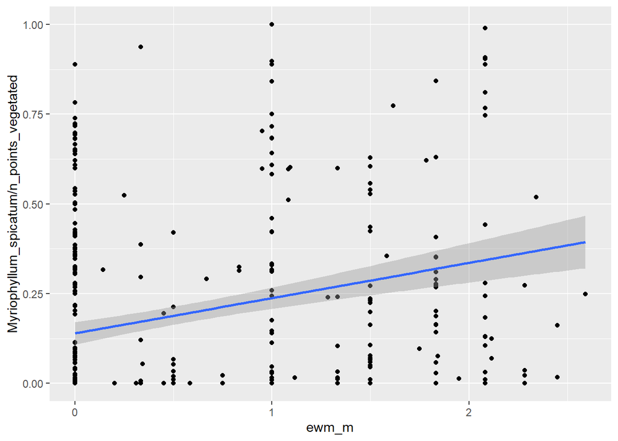

```r
# does management reduce invaders? ----------------------------------------

ggplot(surveys, aes(ewm_m, Myriophyllum_spicatum/n_points_vegetated ) ,)+
  geom_point()+ geom_smooth(method = "lm")
```

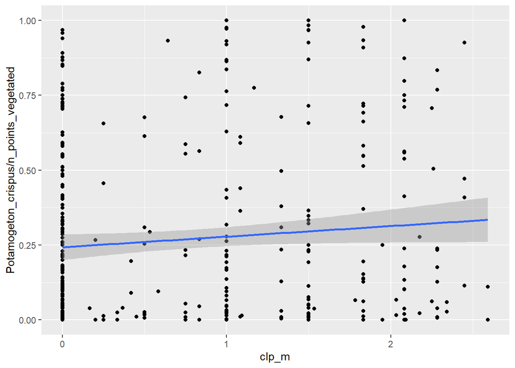

```r
ggplot(surveys, aes(clp_m, Potamogeton_crispus/n_points_vegetated ) ,)+
  geom_point()+ geom_smooth(method = "lm")
```

we can assume if no trt records, that the survey is on a 0 history lake - we’ll do this now are re-visualize (this will add tons of zeros along the x axis)

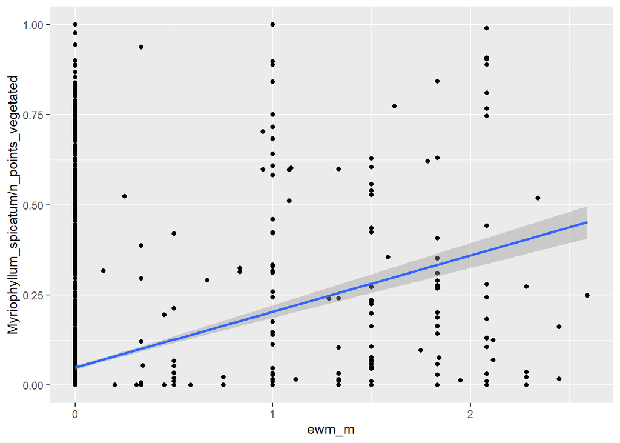

```r
surveys[is.na(clp_m), clp_m:=0]
surveys[is.na(ewm_m), ewm_m:=0]

ggplot(surveys, aes(ewm_m, Myriophyllum_spicatum/n_points_vegetated ) ,)+
  geom_point()+ geom_smooth(method = "lm")
```

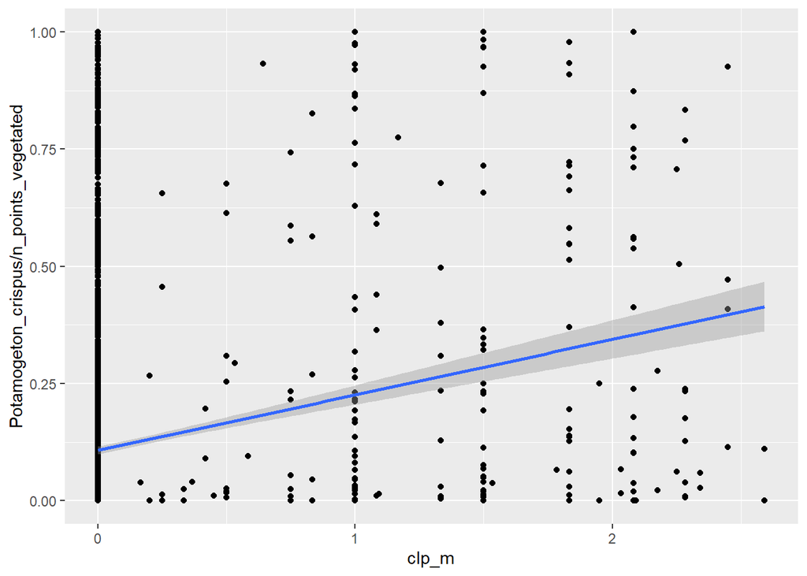

```r
ggplot(surveys, aes(clp_m, Potamogeton_crispus/n_points_vegetated ) ,)+
  geom_point()+ geom_smooth(method = "lm")
```

wozers. that was not helpful: we now see a correllation between more invader management index and more invader. That seems entriely counterintuitive.

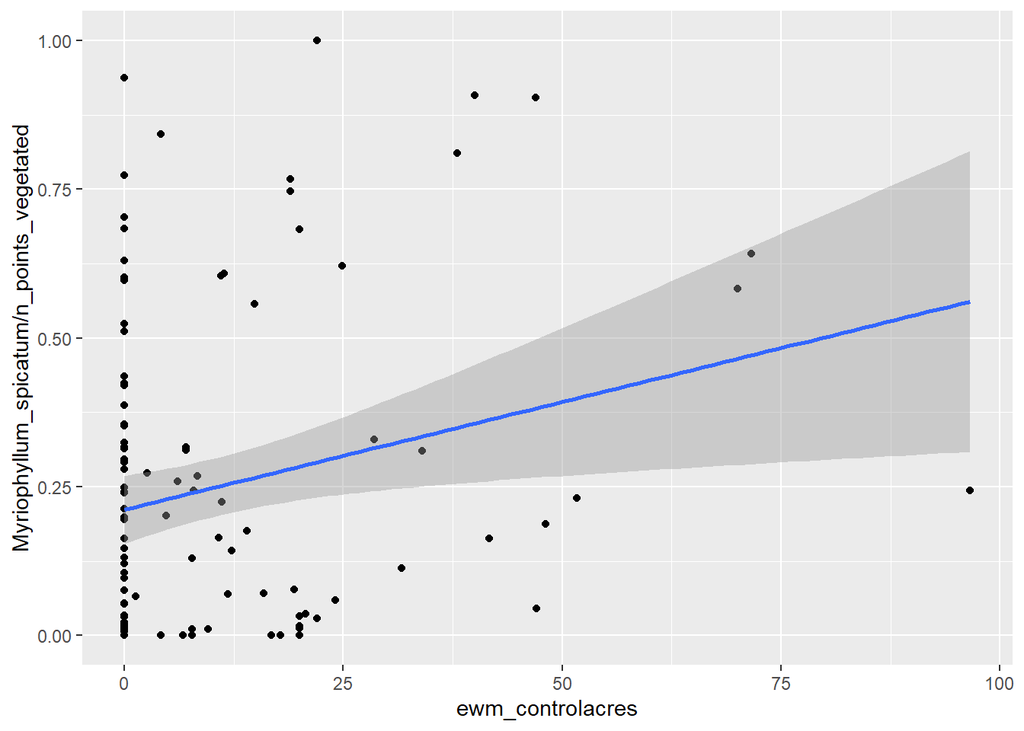

```r
ggplot(surveys[ewm_m > 0 & ewm_pretrt_mod == 0], aes(ewm_controlacres, Myriophyllum_spicatum/n_points_vegetated ) ,)+
  geom_point()+ geom_smooth(method = "lm")
```

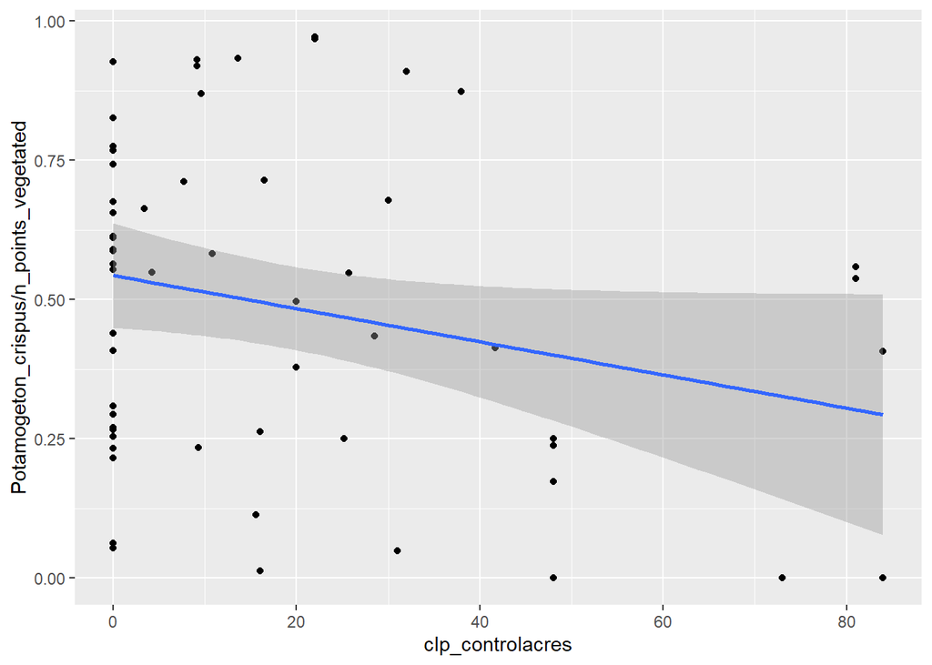

```r
ggplot(surveys[yday(DATESURVEYSTART)<181 & clp_m>0 & clp_pretrt_mod == 0& clp_controlacres<200], aes(clp_controlacres, Potamogeton_crispus/n_points_vegetated ) ,)+
  geom_point()+ geom_smooth(method = "lm")
```

this plot looks really promising, but note that there are TONS of zeros in there (zero EWM abund).

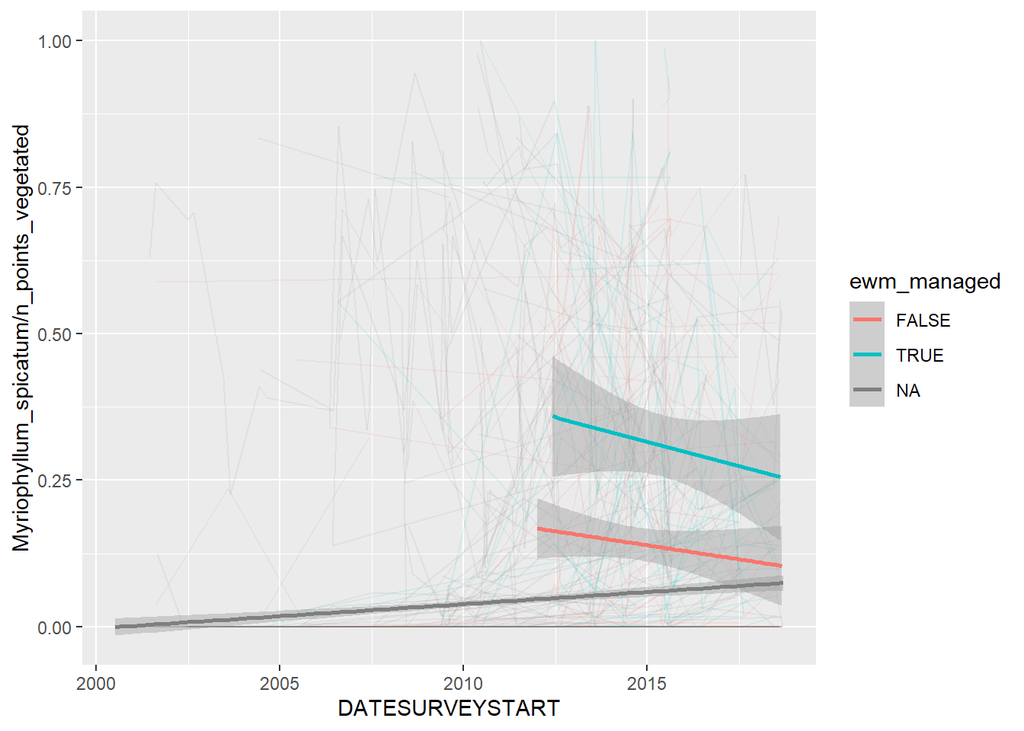

```r
ggplot(surveys[], aes(DATESURVEYSTART, Myriophyllum_spicatum/n_points_vegetated, color = ewm_managed))+
  geom_path(aes(group = DOW), alpha = .1)+
  geom_smooth(method = "lm", )
```

when we pull those out we end up with a much less helpful:

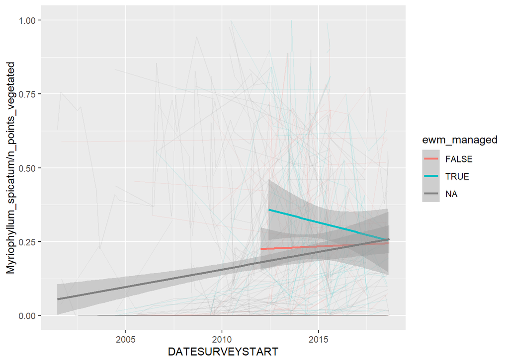

```r
#drop lakes never designated as infested
ggplot(surveys[!is.na(year_EWM_infes)], aes(DATESURVEYSTART, Myriophyllum_spicatum/n_points_vegetated, color = ewm_managed))+
  geom_path(aes(group = DOW), alpha = .1)+
  geom_smooth(method = "lm", )
```

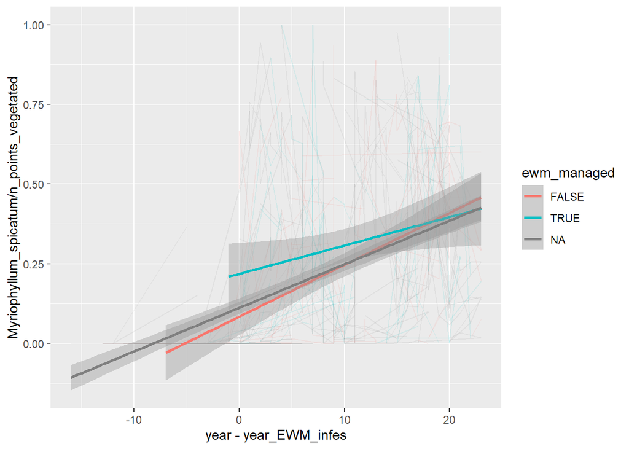

```r
#plot these relative to the "infestation"
ggplot(surveys[!is.na(year_EWM_infes)], aes(year - year_EWM_infes, Myriophyllum_spicatum/n_points_vegetated, color = ewm_managed))+
  geom_path(aes(group = DOW), alpha = .1)+
  geom_smooth(method = "lm", )
```

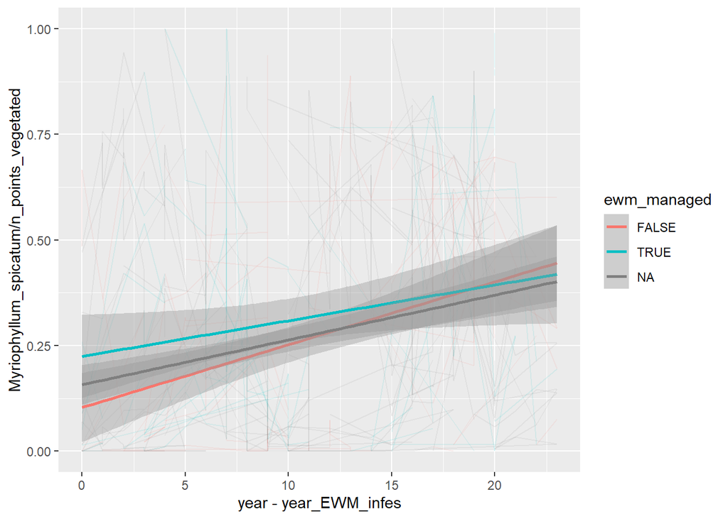

```r
#look only at surveys post infestation
ggplot(surveys[!is.na(year_EWM_infes) & (year - year_EWM_infes)>=0], aes(year - year_EWM_infes, Myriophyllum_spicatum/n_points_vegetated, color = ewm_managed))+
  geom_path(aes(group = DOW), alpha = .1)+
  geom_smooth(method = "lm", )
```

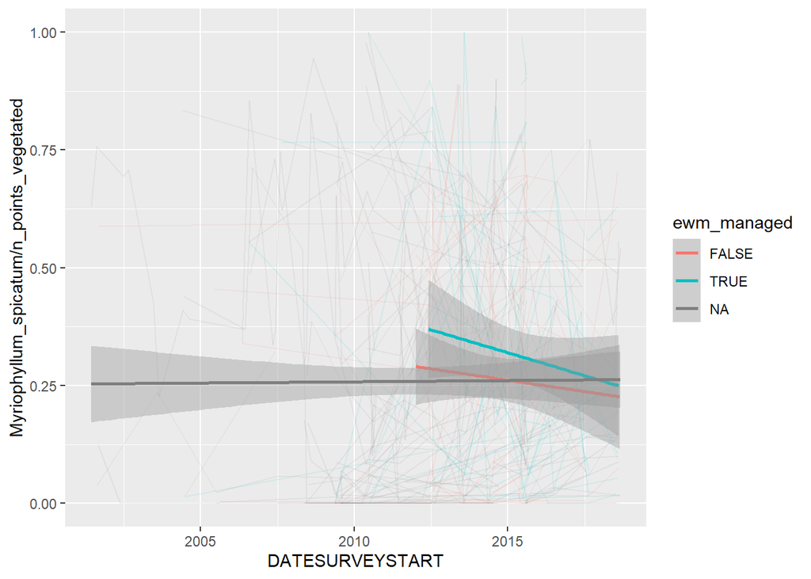

```r
#look only at surveys post infestation
ggplot(surveys[!is.na(year_EWM_infes) & (year - year_EWM_infes)>=0], aes(DATESURVEYSTART, Myriophyllum_spicatum/n_points_vegetated, color = ewm_managed))+
  geom_path(aes(group = DOW), alpha = .1)+
  geom_smooth(method = "lm", )
```

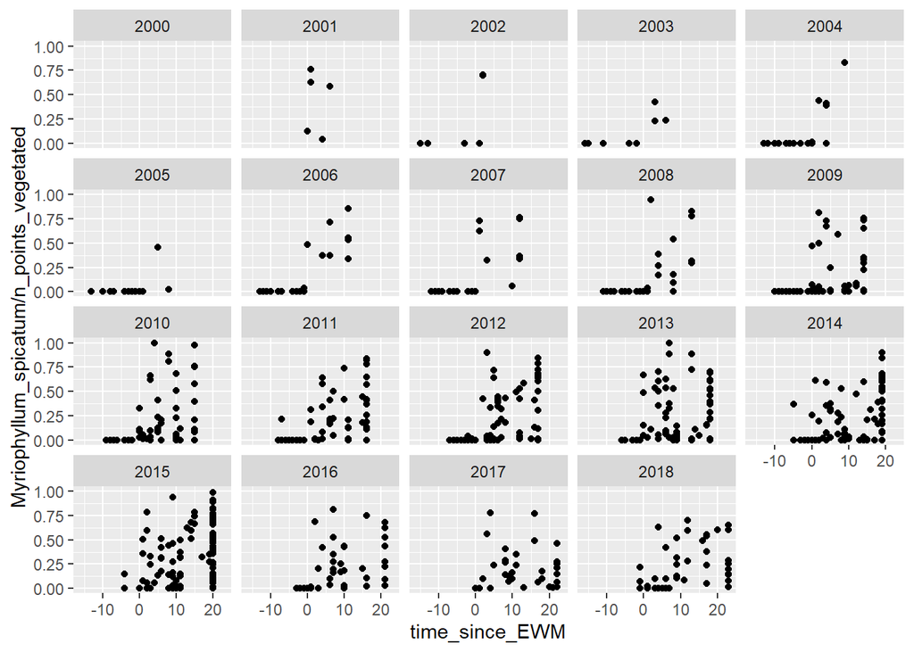

```r
#I suspect this creates an artificial sense of a decline over time because there are low time-since-invasion lakes (with low abund EWM) that are showing up in later years:
surveys[ , time_since_EWM := year - year_EWM_infes ,]

ggplot(surveys[], aes( time_since_EWM, Myriophyllum_spicatum/n_points_vegetated))+
  geom_point()+
  facet_wrap(~year)
```

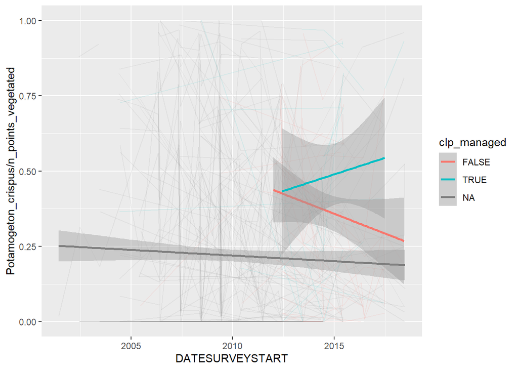

```r
ggplot(surveys[yday(DATESURVEYSTART) < 181 & clp_pretrt_mod == 0], aes(DATESURVEYSTART, Potamogeton_crispus/n_points_vegetated, color = clp_managed))+
  geom_path(aes(group = DOW), alpha = .1)+
  geom_smooth(method = "lm", )
```

Here we can start to see why we need causal inference methods in this analysis. Because treatment decisions are influenced by how much of the invader is there, our most treated lakes are those with the highest abundances of the invader. We need a “counterfactual” that represents how the abundance of invader would have been in lake-year (Xt) had m been zero. It looks to me like we might also have a zero-inflation prob, but we’ll tackle that later.

A simplified look shows the pattern is basically that we’ve got a TON of zero abundance invader lakes in the “control” stack here:

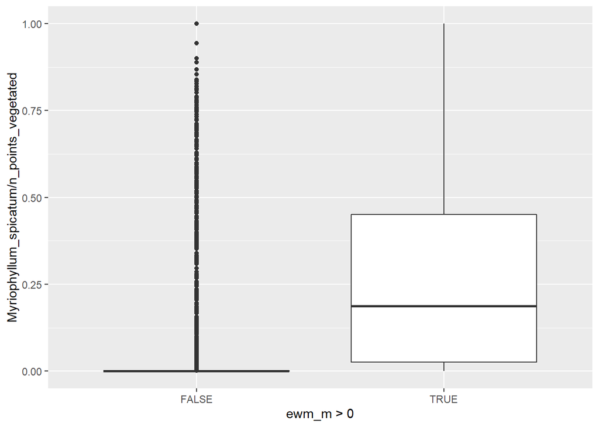

```r
ggplot(surveys[yday(DATESURVEYSTART) > 151], aes(ewm_m>0, Myriophyllum_spicatum/n_points_vegetated ) ,)+
  geom_boxplot()
```

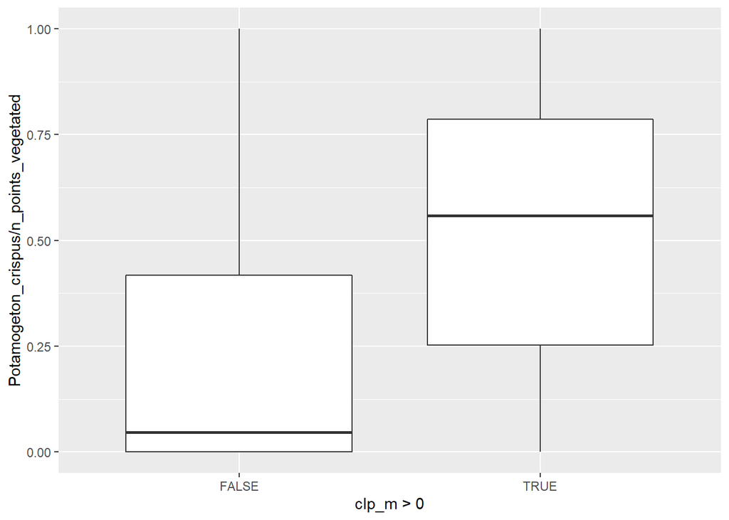

```r
ggplot(surveys[yday(DATESURVEYSTART) < 181], aes(clp_m>0, Potamogeton_crispus/n_points_vegetated ) ,)+
  geom_boxplot()
```

and if we limit this to ONLY lakes with the invader, the prob starts to go away (the effect is less drastic for CLP b/c most early season CLP surveys are done on lakes where we expect CLP to be present):

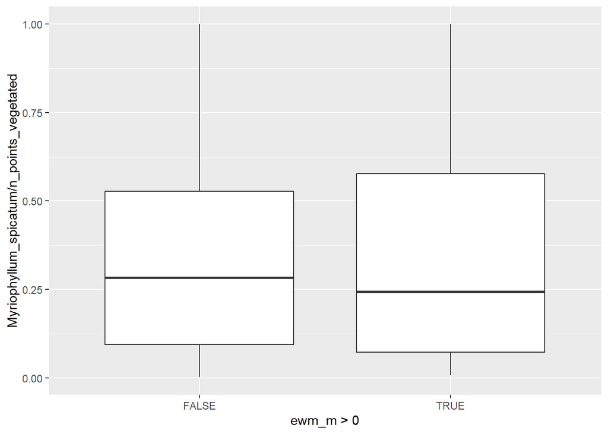

```r
ggplot(surveys[yday(DATESURVEYSTART) > 151 & Myriophyllum_spicatum > 0], aes(ewm_m>0, Myriophyllum_spicatum/n_points_vegetated ) ,)+
  geom_boxplot()
```

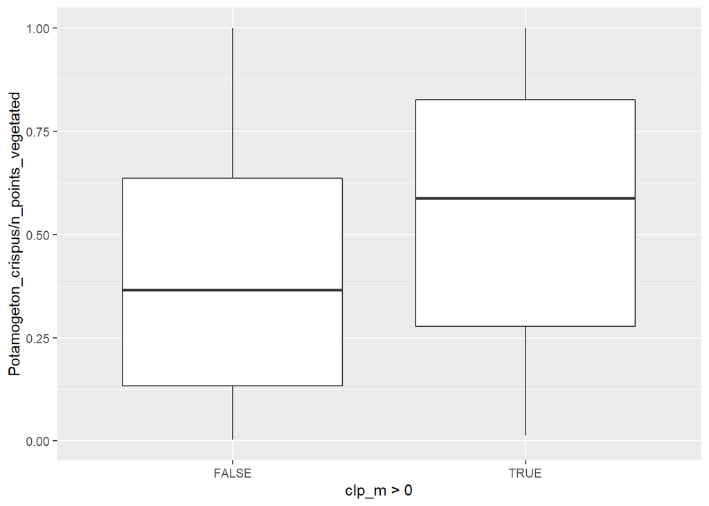

```r
ggplot(surveys[yday(DATESURVEYSTART) < 181 & Potamogeton_crispus > 0], aes(clp_m>0, Potamogeton_crispus/n_points_vegetated ) ,)+
  geom_boxplot()
```

To address this problem, we can use an approach called matching. With matching we will choose a set of “control” surveys that represent a sample from the unmanaged set that are chosen to be good “counterfactuals” for the sample of managed lakes.

From: https://cran.r-project.org/web/packages/MatchIt/vignettes/MatchIt.html The goal of matching is to produce covariate balance, that is, for the distributions of covariates in the two groups to be approximately equal to each other, as they would be in a successful randomized experiment.

Covariates should be those that cause variation in the outcome and selection into treatment group; these are known as confounding variables. See VanderWeele (2019) for a guide on covariate selection. Ideally these covariates are measured without error and are free of missingness.

From VanderWeele: control for each covariate that is a cause of the exposure, or of the outcome, or of both; exclude from this set any variable known to be an instrumental variable; and include as a covariate any proxy for an unmeasured variable that is a common cause of both the exposure and the outcome.

So we need to decide which matching covariates cause var in being chosen for mgmgt and those that cause the invader abund to change. We can see from Shyams paper that MaxDep, SecchiDep, and Lake Area all panned out in the top half of predictors for EWM abund (and P/A, too).

```r
# No matching; constructing a pre-match matchit object


#run matching for EWM:
surveys[is.na(ewm_managed) , ewm_managed := F  , ]

surveys[ ,.N,  is.na(Secchi_m) ]
```

```
##     is.na     N
##    <lgcl> <int>
## 1:  FALSE  2954
## 2:   TRUE   221
```

```r
m.out0 <- matchit(ewm_managed ~ ewm_m_priort + GDD_10C + max_depth_dow + Secchi_m + roads_500m_mperha + as.factor(lake_class),
                  data = surveys[!is.na(Secchi_m) &
                                   !is.na(GDD_10C)&
                                   !is.na(max_depth_dow)&
                                   yday(DATESURVEYSTART) > 151 &
                                   Myriophyllum_spicatum > 0 &
                                   ewm_pretrt_mod == 0],
                  method = NULL, distance = "glm", link = "probit")


# Checking balance prior to matching
summary(m.out0)
```

```
##
## Call:
## matchit(formula = ewm_managed ~ ewm_m_priort + GDD_10C + max_depth_dow +
##     Secchi_m + roads_500m_mperha + as.factor(lake_class), data = surveys[!is.na(Secchi_m) &
##     !is.na(GDD_10C) & !is.na(max_depth_dow) & yday(DATESURVEYSTART) >
##     151 & Myriophyllum_spicatum > 0 & ewm_pretrt_mod == 0], method = NULL,
##     distance = "glm", link = "probit")
##
## Summary of Balance for All Data:
##                           Means Treated Means Control Std. Mean Diff.
## distance                         0.5593        0.0728          1.4771
## ewm_m_priort                     0.6291        0.0397          1.3718
## GDD_10C                       1847.5191     1872.6891         -0.3093
## max_depth_dow                   13.4049       13.2158          0.0191
## Secchi_m                         2.7507        2.2735          0.3044
## roads_500m_mperha               78.3984       65.8702          0.3527
## `as.factor(lake_class)`0         0.0484        0.2263         -0.8289
## `as.factor(lake_class)`22        0.0000        0.0140         -0.1288
## `as.factor(lake_class)`23        0.0645        0.0196          0.1830
## `as.factor(lake_class)`24        0.2903        0.3240         -0.0742
## `as.factor(lake_class)`25        0.0323        0.0140          0.1035
## `as.factor(lake_class)`26        0.0000        0.0168         -0.1412
## `as.factor(lake_class)`27        0.0323        0.0251          0.0403
## `as.factor(lake_class)`29        0.0323        0.0000          0.1826
## `as.factor(lake_class)`30        0.1290        0.0810          0.1433
## `as.factor(lake_class)`32        0.0161        0.0140          0.0172
## `as.factor(lake_class)`35        0.0000        0.0307         -0.1924
## `as.factor(lake_class)`36        0.0000        0.0056         -0.0812
## `as.factor(lake_class)`37        0.0161        0.0140          0.0172
## `as.factor(lake_class)`38        0.1452        0.0754          0.1980
## `as.factor(lake_class)`39        0.0000        0.0140         -0.1288
## `as.factor(lake_class)`40        0.1452        0.0698          0.2138
## `as.factor(lake_class)`41        0.0161        0.0084          0.0615
## `as.factor(lake_class)`42        0.0323        0.0279          0.0245
## `as.factor(lake_class)`43        0.0000        0.0196         -0.1527
##                           Var. Ratio eCDF Mean eCDF Max
## distance                      5.8105    0.4440   0.7682
## ewm_m_priort                  6.0497    0.3506   0.7317
## GDD_10C                       0.7024    0.1099   0.3566
## max_depth_dow                 1.3408    0.0546   0.1260
```

[output cut: 14 more lines]

```
## `as.factor(lake_class)`37          .    0.0022   0.0022
## `as.factor(lake_class)`38          .    0.0697   0.0697
## `as.factor(lake_class)`39          .    0.0140   0.0140
## `as.factor(lake_class)`40          .    0.0753   0.0753
## `as.factor(lake_class)`41          .    0.0077   0.0077
## `as.factor(lake_class)`42          .    0.0043   0.0043
## `as.factor(lake_class)`43          .    0.0196   0.0196
##
##
## Sample Sizes:
##           Control Treated
## All           358      62
## Matched       358      62
## Unmatched       0       0
## Discarded       0       0
```

```r
# 1:1 NN PS matching w/o replacement
m.out1 <- matchit(ewm_managed ~ ewm_m_priort + GDD_10C + max_depth_dow + Secchi_m + roads_500m_mperha + as.factor(lake_class),
                  data = surveys[!is.na(Secchi_m) &
                                   !is.na(GDD_10C)&
                                   !is.na(max_depth_dow)&
                                   yday(DATESURVEYSTART) > 151 &
                                   Myriophyllum_spicatum > 0 &
                                   ewm_pretrt_mod == 0],
                  method = "nearest", distance = "glm", link = "probit")

m.out1
```

```
## A matchit object
##  - method: 1:1 nearest neighbor matching without replacement
##  - distance: Propensity score
##              - estimated with probit regression
##  - number of obs.: 420 (original), 124 (matched)
##  - target estimand: ATT
##  - covariates: ewm_m_priort, GDD_10C, max_depth_dow, Secchi_m, roads_500m_mperha, as.factor(lake_class)
```

```r
# Checking balance after NN matching
summary(m.out1, un = FALSE)
```

```
##
## Call:
## matchit(formula = ewm_managed ~ ewm_m_priort + GDD_10C + max_depth_dow +
##     Secchi_m + roads_500m_mperha + as.factor(lake_class), data = surveys[!is.na(Secchi_m) &
##     !is.na(GDD_10C) & !is.na(max_depth_dow) & yday(DATESURVEYSTART) >
##     151 & Myriophyllum_spicatum > 0 & ewm_pretrt_mod == 0], method = "nearest",
##     distance = "glm", link = "probit")
##
## Summary of Balance for Matched Data:
##                           Means Treated Means Control Std. Mean Diff.
## distance                         0.5593        0.2661          0.8900
## ewm_m_priort                     0.6291        0.2269          0.9361
## GDD_10C                       1847.5191     1831.6681          0.1948
## max_depth_dow                   13.4049       13.3807          0.0024
## Secchi_m                         2.7507        3.3343         -0.3722
## roads_500m_mperha               78.3984       72.9692          0.1528
## `as.factor(lake_class)`0         0.0484        0.0323          0.0752
## `as.factor(lake_class)`22        0.0000        0.0000          0.0000
## `as.factor(lake_class)`23        0.0645        0.1129         -0.1970
## `as.factor(lake_class)`24        0.2903        0.3387         -0.1066
## `as.factor(lake_class)`25        0.0323        0.0161          0.0913
## `as.factor(lake_class)`26        0.0000        0.0000          0.0000
## `as.factor(lake_class)`27        0.0323        0.0484         -0.0913
## `as.factor(lake_class)`29        0.0323        0.0000          0.1826
## `as.factor(lake_class)`30        0.1290        0.0968          0.0962
## `as.factor(lake_class)`32        0.0161        0.0161          0.0000
## `as.factor(lake_class)`35        0.0000        0.0000          0.0000
## `as.factor(lake_class)`36        0.0000        0.0000          0.0000
## `as.factor(lake_class)`37        0.0161        0.0484         -0.2561
## `as.factor(lake_class)`38        0.1452        0.0968          0.1374
## `as.factor(lake_class)`39        0.0000        0.0000          0.0000
## `as.factor(lake_class)`40        0.1452        0.0968          0.1374
## `as.factor(lake_class)`41        0.0161        0.0484         -0.2561
## `as.factor(lake_class)`42        0.0323        0.0484         -0.0913
## `as.factor(lake_class)`43        0.0000        0.0000          0.0000
##                           Var. Ratio eCDF Mean eCDF Max Std. Pair Dist.
## distance                      1.8295    0.0822   0.5000          0.8901
## ewm_m_priort                  1.3659    0.2413   0.4839          1.0474
## GDD_10C                       0.4948    0.0460   0.1452          1.2939
## max_depth_dow                 1.2541    0.0413   0.1129          1.0806
```

[output cut: 13 more lines]

```
## `as.factor(lake_class)`36          .    0.0000   0.0000          0.0000
## `as.factor(lake_class)`37          .    0.0323   0.0323          0.5121
## `as.factor(lake_class)`38          .    0.0484   0.0484          0.6868
## `as.factor(lake_class)`39          .    0.0000   0.0000          0.0000
## `as.factor(lake_class)`40          .    0.0484   0.0484          0.6868
## `as.factor(lake_class)`41          .    0.0323   0.0323          0.5121
## `as.factor(lake_class)`42          .    0.0161   0.0161          0.4564
## `as.factor(lake_class)`43          .    0.0000   0.0000          0.0000
##
## Sample Sizes:
##           Control Treated
## All           358      62
## Matched        62      62
## Unmatched     296       0
## Discarded       0       0
```

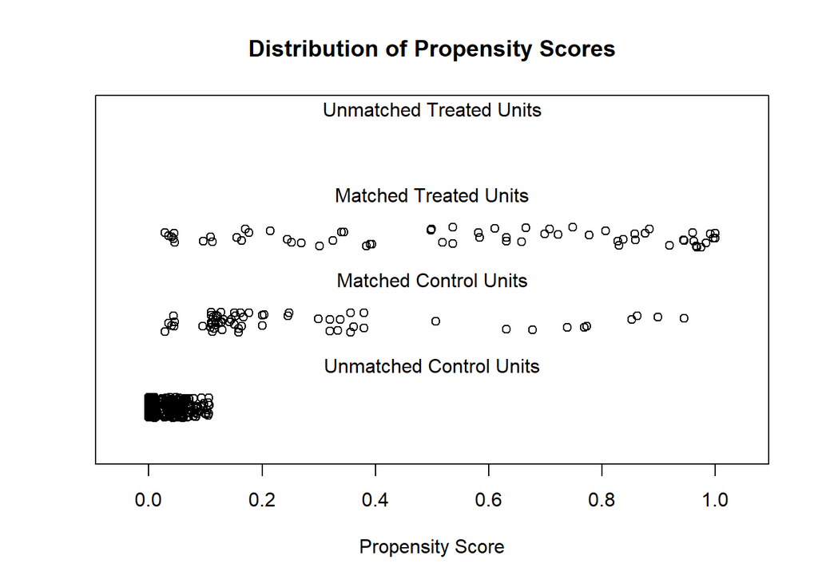

```r
plot(m.out1, type = "jitter", interactive = FALSE)
```

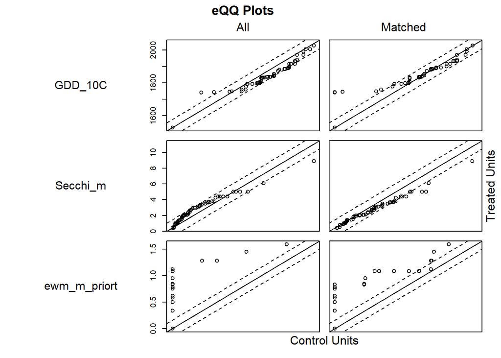

```r
plot(m.out1, type = "qq", interactive = FALSE,
     which.xs = c("GDD_10C", "Secchi_m", "ewm_m_priort"))
```

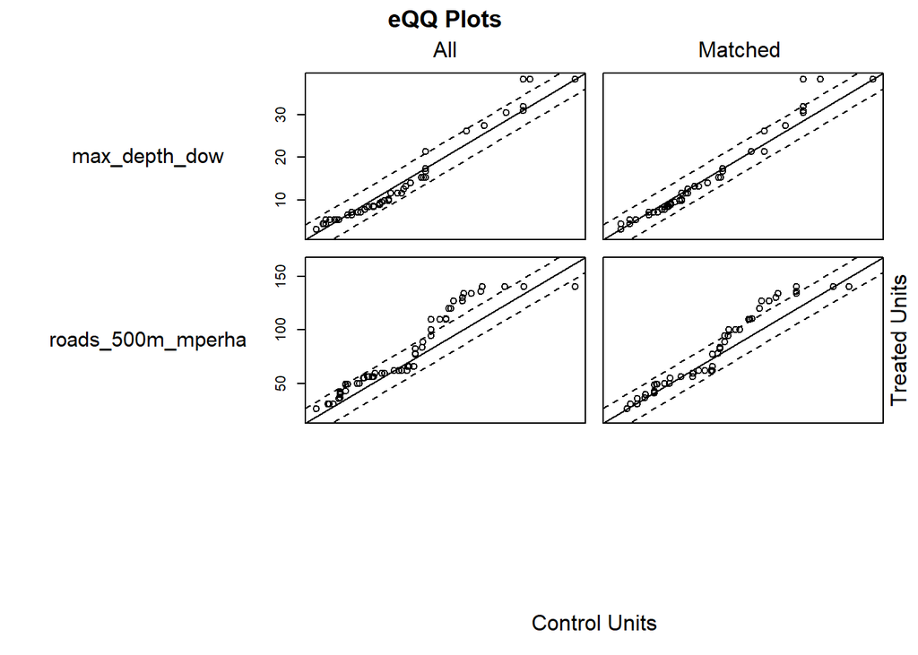

```r
plot(m.out1, type = "qq", interactive = FALSE,
     which.xs = c("max_depth_dow", "roads_500m_mperha"))
```

```r
# Full matching on a probit PS
m.out2 <- matchit(ewm_managed ~ ewm_m_priort + GDD_10C + max_depth_dow + Secchi_m + roads_500m_mperha + as.factor(lake_class),
                  data = surveys[!is.na(Secchi_m) &
                                   !is.na(GDD_10C)&
                                   !is.na(max_depth_dow)&
                                   yday(DATESURVEYSTART) > 151 &
                                   Myriophyllum_spicatum > 0 &
                                   ewm_pretrt_mod == 0],
                  method = "full", distance = "glm", link = "probit")
m.out2
```

```
## A matchit object
##  - method: Optimal full matching
##  - distance: Propensity score
##              - estimated with probit regression
##  - number of obs.: 420 (original), 420 (matched)
##  - target estimand: ATT
##  - covariates: ewm_m_priort, GDD_10C, max_depth_dow, Secchi_m, roads_500m_mperha, as.factor(lake_class)
```

```r
# Checking balance after full matching
summary(m.out2, un = FALSE)
```

```
##
## Call:
## matchit(formula = ewm_managed ~ ewm_m_priort + GDD_10C + max_depth_dow +
##     Secchi_m + roads_500m_mperha + as.factor(lake_class), data = surveys[!is.na(Secchi_m) &
##     !is.na(GDD_10C) & !is.na(max_depth_dow) & yday(DATESURVEYSTART) >
##     151 & Myriophyllum_spicatum > 0 & ewm_pretrt_mod == 0], method = "full",
##     distance = "glm", link = "probit")
##
## Summary of Balance for Matched Data:
##                           Means Treated Means Control Std. Mean Diff.
## distance                         0.5593        0.5530          0.0189
## ewm_m_priort                     0.6291        0.6298         -0.0017
## GDD_10C                       1847.5191     1858.3939         -0.1336
## max_depth_dow                   13.4049       12.2101          0.1207
## Secchi_m                         2.7507        2.6615          0.0569
## roads_500m_mperha               78.3984       74.2524          0.1167
## `as.factor(lake_class)`0         0.0484        0.0257          0.1057
## `as.factor(lake_class)`22        0.0000        0.0005         -0.0049
## `as.factor(lake_class)`23        0.0645        0.0557          0.0361
## `as.factor(lake_class)`24        0.2903        0.3547         -0.1418
## `as.factor(lake_class)`25        0.0323        0.0037          0.1616
## `as.factor(lake_class)`26        0.0000        0.0006         -0.0053
## `as.factor(lake_class)`27        0.0323        0.0054          0.1521
## `as.factor(lake_class)`29        0.0323        0.0000          0.1826
## `as.factor(lake_class)`30        0.1290        0.2811         -0.4537
## `as.factor(lake_class)`32        0.0161        0.0186         -0.0195
## `as.factor(lake_class)`35        0.0000        0.0012         -0.0073
## `as.factor(lake_class)`36        0.0000        0.0002         -0.0031
## `as.factor(lake_class)`37        0.0161        0.0139          0.0179
## `as.factor(lake_class)`38        0.1452        0.1250          0.0571
## `as.factor(lake_class)`39        0.0000        0.0005         -0.0049
## `as.factor(lake_class)`40        0.1452        0.0258          0.3389
## `as.factor(lake_class)`41        0.0161        0.0496         -0.2659
## `as.factor(lake_class)`42        0.0323        0.0371         -0.0271
## `as.factor(lake_class)`43        0.0000        0.0007         -0.0058
##                           Var. Ratio eCDF Mean eCDF Max Std. Pair Dist.
## distance                      0.9830    0.0114   0.1774          0.0421
## ewm_m_priort                  0.6929    0.0701   0.1774          0.0981
## GDD_10C                       0.7219    0.0616   0.2173          1.2046
## max_depth_dow                 2.4453    0.0936   0.2453          0.7566
```

[output cut: 14 more lines]

```
## `as.factor(lake_class)`37          .    0.0022   0.0022          0.5729
## `as.factor(lake_class)`38          .    0.0201   0.0201          0.3146
## `as.factor(lake_class)`39          .    0.0005   0.0005          0.1188
## `as.factor(lake_class)`40          .    0.1194   0.1194          0.2488
## `as.factor(lake_class)`41          .    0.0335   0.0335          0.1023
## `as.factor(lake_class)`42          .    0.0048   0.0048          0.2042
## `as.factor(lake_class)`43          .    0.0007   0.0007          0.1409
##
## Sample Sizes:
##               Control Treated
## All            358.        62
## Matched (ESS)   15.14      62
## Matched        358.        62
## Unmatched        0.         0
## Discarded        0.         0
```

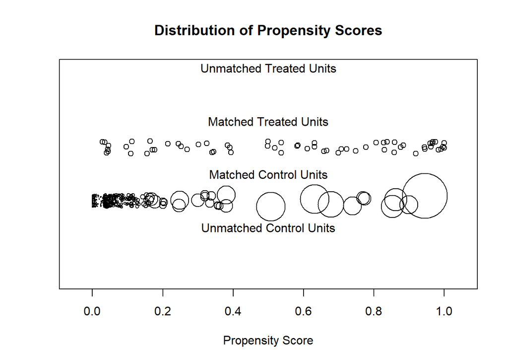

```r
plot(m.out2, type = "jitter", interactive = FALSE)
```

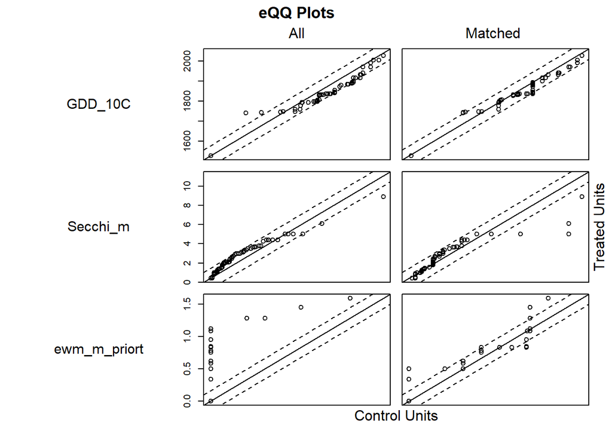

```r
plot(m.out2, type = "qq", interactive = FALSE,
     which.xs = c("GDD_10C", "Secchi_m", "ewm_m_priort"))
```

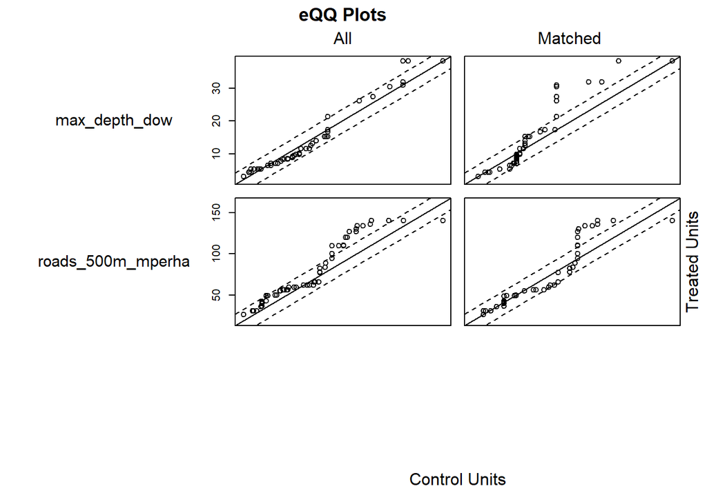

```r
plot(m.out2, type = "qq", interactive = FALSE,
     which.xs = c("max_depth_dow", "roads_500m_mperha"))
```

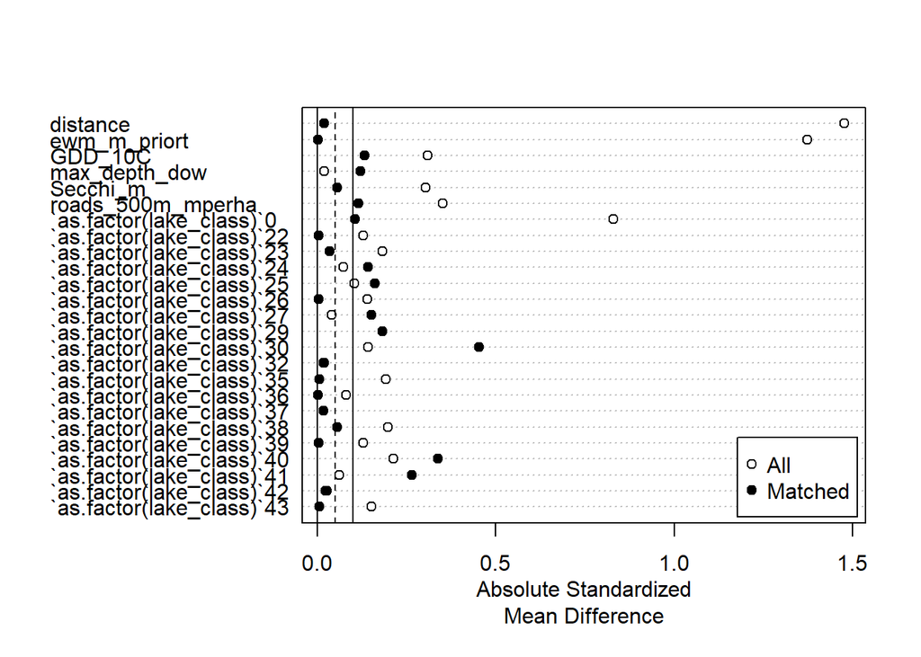

```r
plot(summary(m.out2))
```

```r
# EWM - Analysis of matched set of survey data ----------------------------------------

m.data1 <- match.data(m.out1)

head(m.data1)
```

```
##    ewm_pretrt clp_pretrt      DOW  year DATESURVEYSTART SUBBASIN clp_ntrtdates
##         <int>      <int>    <int> <int>          <IDat>   <char>         <int>
## 1:         NA          0 40000200  2014      2014-07-07                      1
## 2:          0          0 40006300  2015      2015-06-09                      1
## 3:         NA         NA 86005300  2018      2018-07-20                      0
## 4:          0          0 10000900  2014      2014-06-11                      1
## 5:         NA         NA 10001200  2011      2011-07-06                     NA
## 6:         NA         NA 10004100  2016      2016-06-07    Sunny            NA
##       clp_m ewm_ntrtdates    ewm_m ntrtdates        m fw_id dowlknum
##       <num>         <int>    <num>     <int>    <num> <int>    <int>
## 1: 1.833333             0 0.000000         1 1.833333  3391 40000200
## 2: 1.500000             1 1.000000         2 1.500000  3373 40006300
## 3: 1.092857             0 1.092857         0 1.092857 88888 86005302
## 4: 1.833333             1 1.833333         1 1.833333  3207 10000900
## 5: 0.000000            NA 0.000000        NA 0.000000  3218 10001200
```

[output cut: 641 more lines]

```r
#Test for effect on invader abund:

fit1 <- glm(Myriophyllum_spicatum/n_points_vegetated ~ ewm_managed + ewm_m_priort + GDD_10C + max_depth_dow + Secchi_m + roads_500m_mperha + as.factor(lake_class)  , data = m.data1, weights = weights, family = binomial(link = "logit"))
coeftest(fit1, vcov. = vcovCL, cluster = ~subclass)
```

```
##
## z test of coefficients:
##
##                            Estimate  Std. Error z value  Pr(>|z|)
## (Intercept)             -12.5152458   3.1158229 -4.0167 5.903e-05 ***
## ewm_managedTRUE           0.0849952   0.2298342  0.3698 0.7115234
## ewm_m_priort             -0.4478712   0.2436618 -1.8381 0.0660498 .
## GDD_10C                   0.0057781   0.0015526  3.7214 0.0001981 ***
## max_depth_dow             0.0431534   0.0243698  1.7708 0.0765986 .
## Secchi_m                 -0.1608101   0.0963112 -1.6697 0.0949802 .
## roads_500m_mperha         0.0062847   0.0041296  1.5219 0.1280427
## as.factor(lake_class)23   1.2138578   0.9518576  1.2753 0.2022202
## as.factor(lake_class)24   0.8321540   0.8199968  1.0148 0.3101888
## as.factor(lake_class)25  -0.8059544   1.0128712 -0.7957 0.4261991
## as.factor(lake_class)27   1.2789836   1.0208667  1.2528 0.2102636
## as.factor(lake_class)29   0.5382355   1.1130017  0.4836 0.6286775
## as.factor(lake_class)30   0.2659575   0.8958001  0.2969 0.7665476
## as.factor(lake_class)32   0.0489728   1.1544045  0.0424 0.9661619
## as.factor(lake_class)37   1.8696386   1.3646259  1.3701 0.1706638
## as.factor(lake_class)38   0.3660492   0.9023192  0.4057 0.6849807
## as.factor(lake_class)40   0.6154212   0.9247222  0.6655 0.5057179
## as.factor(lake_class)41   1.0308330   1.1271685  0.9145 0.3604367
## as.factor(lake_class)42  -3.0008698   1.0144844 -2.9580 0.0030962 **
## ---
## Signif. codes:  0 '***' 0.001 '**' 0.01 '*' 0.05 '.' 0.1 ' ' 1
```

```r
#and recall full match had better balance:

m.data2 <- match.data(m.out2)

fit2 <- glm(Myriophyllum_spicatum/n_points_vegetated ~ ewm_managed + ewm_m_priort + GDD_10C + max_depth_dow + Secchi_m + roads_500m_mperha + as.factor(lake_class)  , data = m.data2, weights = weights, family = binomial(link = "logit"))
coeftest(fit2, vcov. = vcovCL, cluster = ~subclass)
```

```
##
## z test of coefficients:
##
##                            Estimate  Std. Error z value  Pr(>|z|)
## (Intercept)             -10.6033098   2.4602896 -4.3098 1.634e-05 ***
## ewm_managedTRUE          -0.1050241   0.1868315 -0.5621 0.5740258
## ewm_m_priort             -0.0827256   0.2127666 -0.3888 0.6974175
## GDD_10C                   0.0048257   0.0013447  3.5887 0.0003323 ***
## max_depth_dow             0.0506645   0.0241664  2.0965 0.0360394 *
## Secchi_m                  0.0273460   0.0566975  0.4823 0.6295836
## roads_500m_mperha         0.0038563   0.0035929  1.0733 0.2831411
## as.factor(lake_class)22  -0.9025475   0.5361003 -1.6835 0.0922702 .
## as.factor(lake_class)23  -0.0677139   0.6796678 -0.0996 0.9206397
## as.factor(lake_class)24   0.2757735   0.5382697  0.5123 0.6084177
## as.factor(lake_class)25  -2.0651148   0.9119117 -2.2646 0.0235373 *
## as.factor(lake_class)26  -0.3023792   0.5703931 -0.5301 0.5960259
## as.factor(lake_class)27   0.2621520   0.7291964  0.3595 0.7192151
## as.factor(lake_class)29   0.0048966   0.5494646  0.0089 0.9928897
## as.factor(lake_class)30  -0.5814617   0.5468290 -1.0633 0.2876307
## as.factor(lake_class)32  -0.1947237   0.7439730 -0.2617 0.7935259
## as.factor(lake_class)35  -0.2526123   0.5876771 -0.4298 0.6673056
## as.factor(lake_class)36  -2.7582443   0.6102015 -4.5202 6.178e-06 ***
## as.factor(lake_class)37   1.2423725   0.8066140  1.5402 0.1235038
## as.factor(lake_class)38  -0.0861525   0.6347326 -0.1357 0.8920345
## as.factor(lake_class)39   0.7034673   0.6791649  1.0358 0.3003035
## as.factor(lake_class)40   0.2770933   0.6988173  0.3965 0.6917233
## as.factor(lake_class)41   1.4211672   0.6270556  2.2664 0.0234261 *
## as.factor(lake_class)42  -2.7168974   0.7083829 -3.8354 0.0001254 ***
## as.factor(lake_class)43  -0.4172311   0.6998286 -0.5962 0.5510480
## ---
## Signif. codes:  0 '***' 0.001 '**' 0.01 '*' 0.05 '.' 0.1 ' ' 1
```

```r
#repeat matching steps for CLP:

surveys[is.na(clp_managed) , clp_managed := F  , ]

surveys[ ,.N,  Secchi_m ]
```

```
##      Secchi_m     N
##         <num> <int>
##   1:  0.91440    63
##   2:  1.05156     1
##   3:  3.65760     8
##   4:  3.00000    20
##   5:  3.96240    12
##  ---
## 553:  2.75000     1
## 554:  0.30550     1
## 555:  1.40940     1
## 556:  0.89530     1
## 557:  0.21430     1
```

```r
m.out0.1 <- matchit(clp_managed ~  clp_m_priort + GDD_10C + max_depth_dow + Secchi_m + roads_500m_mperha + as.factor(lake_class),
                  data = surveys[!is.na(Secchi_m) &
                                   !is.na(GDD_10C)&
                                   !is.na(max_depth_dow)&
                                   !is.na(roads_500m_mperha) &
                                   yday(DATESURVEYSTART) < 181 &
                                   clp_pretrt_mod == 0],
                  method = NULL, distance = "glm", link = "probit")


# Checking balance prior to matching
summary(m.out0.1)
```

```
##
## Call:
## matchit(formula = clp_managed ~ clp_m_priort + GDD_10C + max_depth_dow +
##     Secchi_m + roads_500m_mperha + as.factor(lake_class), data = surveys[!is.na(Secchi_m) &
##     !is.na(GDD_10C) & !is.na(max_depth_dow) & !is.na(roads_500m_mperha) &
##     yday(DATESURVEYSTART) < 181 & clp_pretrt_mod == 0], method = NULL,
##     distance = "glm", link = "probit")
##
## Summary of Balance for All Data:
##                           Means Treated Means Control Std. Mean Diff.
## distance                         0.4651        0.0321          1.2019
## clp_m_priort                     0.5797        0.0214          1.2769
## GDD_10C                       1906.9807     1808.9918          0.8810
## max_depth_dow                    7.1766        8.9766         -0.3008
## Secchi_m                         1.9039        2.4347         -0.3570
## roads_500m_mperha               69.0543       51.2660          0.5568
## `as.factor(lake_class)`0         0.0732        0.1527         -0.3054
## `as.factor(lake_class)`12        0.0000        0.0015         -0.0399
## `as.factor(lake_class)`13        0.0000        0.0015         -0.0399
## `as.factor(lake_class)`16        0.0000        0.0030         -0.0565
## `as.factor(lake_class)`17        0.0000        0.0030         -0.0565
## `as.factor(lake_class)`21        0.0000        0.0015         -0.0399
## `as.factor(lake_class)`22        0.0000        0.0165         -0.1332
## `as.factor(lake_class)`23        0.0000        0.0240         -0.1613
## `as.factor(lake_class)`24        0.2439        0.1557          0.2054
## `as.factor(lake_class)`25        0.0244        0.0195          0.0320
## `as.factor(lake_class)`26        0.0000        0.0030         -0.0565
## `as.factor(lake_class)`27        0.0000        0.0269         -0.1713
## `as.factor(lake_class)`28        0.0000        0.0060         -0.0799
## `as.factor(lake_class)`29        0.0244        0.0554         -0.2010
## `as.factor(lake_class)`30        0.0244        0.0539         -0.1913
## `as.factor(lake_class)`31        0.0000        0.0225         -0.1560
## `as.factor(lake_class)`32        0.0000        0.0060         -0.0799
## `as.factor(lake_class)`33        0.0000        0.0015         -0.0399
## `as.factor(lake_class)`34        0.0000        0.0389         -0.2071
## `as.factor(lake_class)`35        0.0000        0.0060         -0.0799
## `as.factor(lake_class)`36        0.0000        0.0060         -0.0799
## `as.factor(lake_class)`37        0.0732        0.0105          0.2407
## `as.factor(lake_class)`38        0.0976        0.0584          0.1320
## `as.factor(lake_class)`39        0.0244        0.0434         -0.1233
```

[output cut: 32 more lines]

```
## `as.factor(lake_class)`37          .    0.0627   0.0627
## `as.factor(lake_class)`38          .    0.0392   0.0392
## `as.factor(lake_class)`39          .    0.0190   0.0190
## `as.factor(lake_class)`40          .    0.0546   0.0546
## `as.factor(lake_class)`41          .    0.0283   0.0283
## `as.factor(lake_class)`42          .    0.0009   0.0009
## `as.factor(lake_class)`43          .    0.0480   0.0480
##
##
## Sample Sizes:
##           Control Treated
## All           668      41
## Matched       668      41
## Unmatched       0       0
## Discarded       0       0
```

```r
# 1:1 NN PS matching w/o replacement
m.out1.1 <- matchit(clp_managed ~  clp_m_priort + GDD_10C + max_depth_dow + Secchi_m + roads_500m_mperha + as.factor(lake_class),
                  data = surveys[!is.na(Secchi_m) &
                                   !is.na(GDD_10C)&
                                   !is.na(max_depth_dow)&
                                   !is.na(roads_500m_mperha)&
                                   yday(DATESURVEYSTART) < 181 &
                                   ewm_pretrt_mod == 0],
                  method = "nearest", distance = "glm", link = "probit")

m.out1.1
```

```
## A matchit object
##  - method: 1:1 nearest neighbor matching without replacement
##  - distance: Propensity score
##              - estimated with probit regression
##  - number of obs.: 710 (original), 128 (matched)
##  - target estimand: ATT
##  - covariates: clp_m_priort, GDD_10C, max_depth_dow, Secchi_m, roads_500m_mperha, as.factor(lake_class)
```

```r
# Checking balance after NN matching
summary(m.out1, un = FALSE)
```

```
##
## Call:
## matchit(formula = ewm_managed ~ ewm_m_priort + GDD_10C + max_depth_dow +
##     Secchi_m + roads_500m_mperha + as.factor(lake_class), data = surveys[!is.na(Secchi_m) &
##     !is.na(GDD_10C) & !is.na(max_depth_dow) & yday(DATESURVEYSTART) >
##     151 & Myriophyllum_spicatum > 0 & ewm_pretrt_mod == 0], method = "nearest",
##     distance = "glm", link = "probit")
##
## Summary of Balance for Matched Data:
##                           Means Treated Means Control Std. Mean Diff.
## distance                         0.5593        0.2661          0.8900
## ewm_m_priort                     0.6291        0.2269          0.9361
## GDD_10C                       1847.5191     1831.6681          0.1948
## max_depth_dow                   13.4049       13.3807          0.0024
## Secchi_m                         2.7507        3.3343         -0.3722
## roads_500m_mperha               78.3984       72.9692          0.1528
## `as.factor(lake_class)`0         0.0484        0.0323          0.0752
## `as.factor(lake_class)`22        0.0000        0.0000          0.0000
## `as.factor(lake_class)`23        0.0645        0.1129         -0.1970
## `as.factor(lake_class)`24        0.2903        0.3387         -0.1066
## `as.factor(lake_class)`25        0.0323        0.0161          0.0913
## `as.factor(lake_class)`26        0.0000        0.0000          0.0000
## `as.factor(lake_class)`27        0.0323        0.0484         -0.0913
## `as.factor(lake_class)`29        0.0323        0.0000          0.1826
## `as.factor(lake_class)`30        0.1290        0.0968          0.0962
## `as.factor(lake_class)`32        0.0161        0.0161          0.0000
## `as.factor(lake_class)`35        0.0000        0.0000          0.0000
## `as.factor(lake_class)`36        0.0000        0.0000          0.0000
## `as.factor(lake_class)`37        0.0161        0.0484         -0.2561
## `as.factor(lake_class)`38        0.1452        0.0968          0.1374
## `as.factor(lake_class)`39        0.0000        0.0000          0.0000
## `as.factor(lake_class)`40        0.1452        0.0968          0.1374
## `as.factor(lake_class)`41        0.0161        0.0484         -0.2561
## `as.factor(lake_class)`42        0.0323        0.0484         -0.0913
## `as.factor(lake_class)`43        0.0000        0.0000          0.0000
##                           Var. Ratio eCDF Mean eCDF Max Std. Pair Dist.
## distance                      1.8295    0.0822   0.5000          0.8901
## ewm_m_priort                  1.3659    0.2413   0.4839          1.0474
## GDD_10C                       0.4948    0.0460   0.1452          1.2939
## max_depth_dow                 1.2541    0.0413   0.1129          1.0806
```

[output cut: 13 more lines]

```
## `as.factor(lake_class)`36          .    0.0000   0.0000          0.0000
## `as.factor(lake_class)`37          .    0.0323   0.0323          0.5121
## `as.factor(lake_class)`38          .    0.0484   0.0484          0.6868
## `as.factor(lake_class)`39          .    0.0000   0.0000          0.0000
## `as.factor(lake_class)`40          .    0.0484   0.0484          0.6868
## `as.factor(lake_class)`41          .    0.0323   0.0323          0.5121
## `as.factor(lake_class)`42          .    0.0161   0.0161          0.4564
## `as.factor(lake_class)`43          .    0.0000   0.0000          0.0000
##
## Sample Sizes:
##           Control Treated
## All           358      62
## Matched        62      62
## Unmatched     296       0
## Discarded       0       0
```

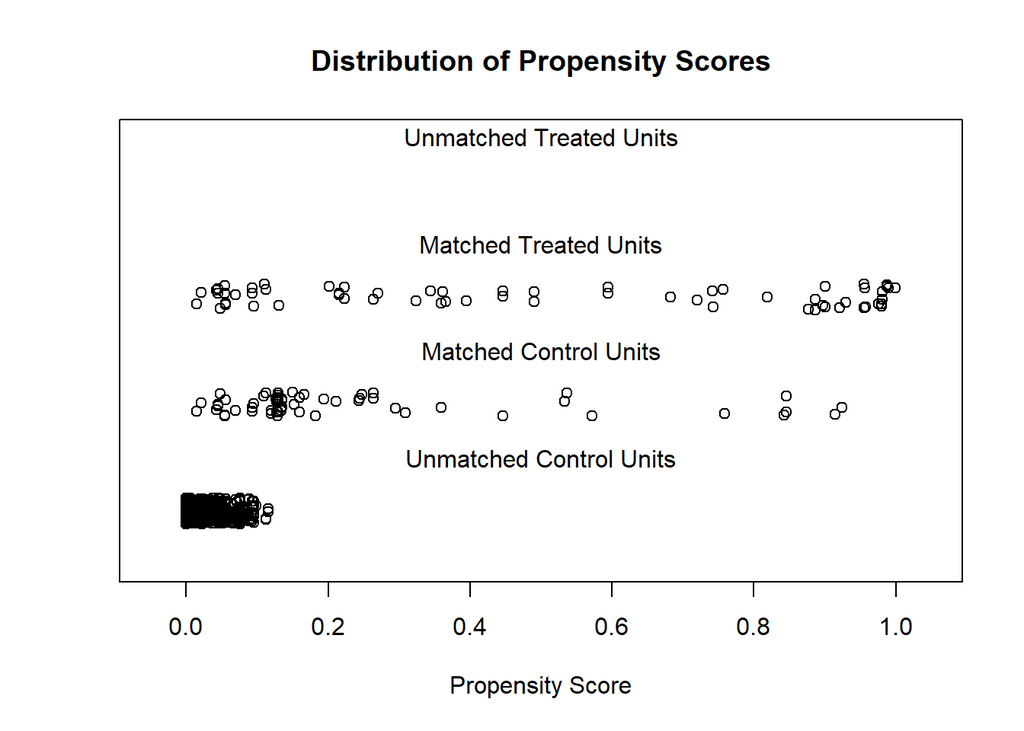

```r
plot(m.out1.1, type = "jitter", interactive = FALSE)
```

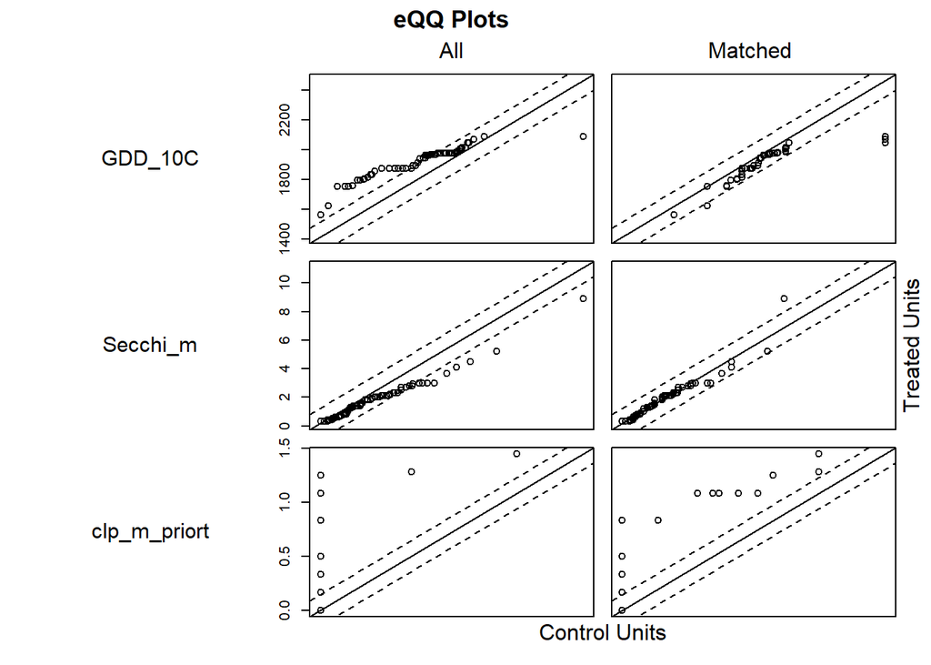

```r
plot(m.out1.1, type = "qq", interactive = FALSE,
     which.xs = c("GDD_10C", "Secchi_m", "clp_m_priort"))
```

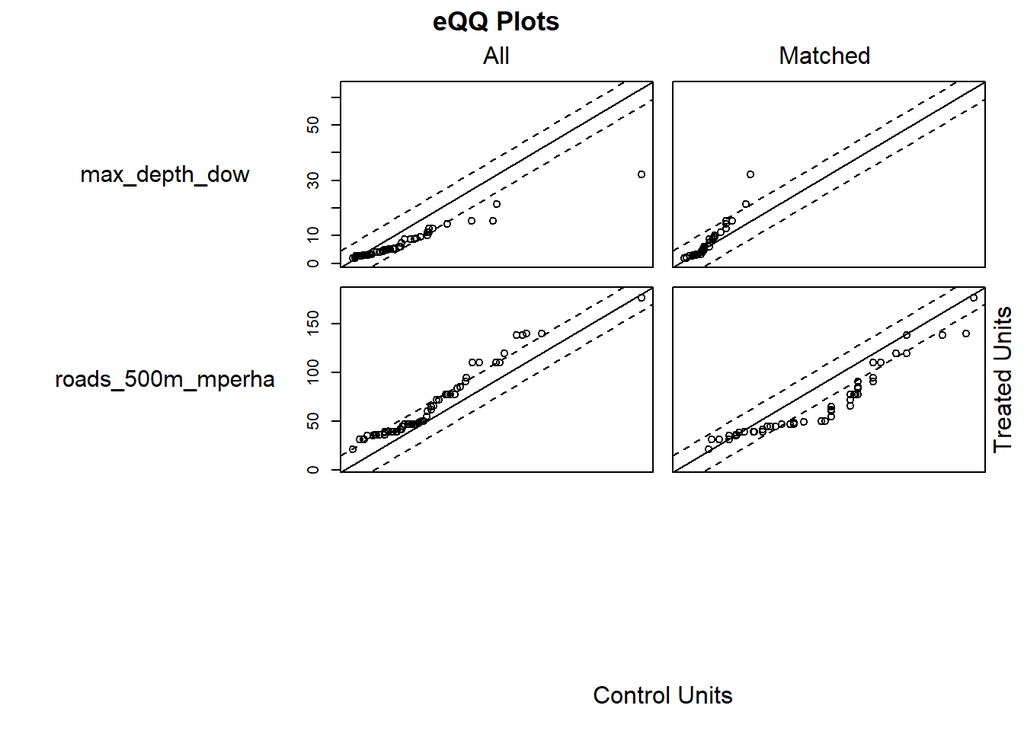

```r
plot(m.out1.1, type = "qq", interactive = FALSE,
     which.xs = c("max_depth_dow", "roads_500m_mperha"))
```

```r
# Full matching on a probit PS
m.out2.1 <- matchit(clp_managed ~  clp_m_priort + GDD_10C + max_depth_dow + Secchi_m + roads_500m_mperha + as.factor(lake_class),
                  data = surveys[!is.na(Secchi_m) &
                                   !is.na(GDD_10C)&
                                   !is.na(max_depth_dow)&
                                   !is.na(roads_500m_mperha)&
                                   yday(DATESURVEYSTART) < 181 &
                                   ewm_pretrt_mod == 0],
                  method = "full", distance = "glm", link = "probit")
m.out2.1
```

```
## A matchit object
##  - method: Optimal full matching
##  - distance: Propensity score
##              - estimated with probit regression
##  - number of obs.: 710 (original), 710 (matched)
##  - target estimand: ATT
##  - covariates: clp_m_priort, GDD_10C, max_depth_dow, Secchi_m, roads_500m_mperha, as.factor(lake_class)
```

```r
# Checking balance after full matching
summary(m.out2.1, un = FALSE)
```

```
##
## Call:
## matchit(formula = clp_managed ~ clp_m_priort + GDD_10C + max_depth_dow +
##     Secchi_m + roads_500m_mperha + as.factor(lake_class), data = surveys[!is.na(Secchi_m) &
##     !is.na(GDD_10C) & !is.na(max_depth_dow) & !is.na(roads_500m_mperha) &
##     yday(DATESURVEYSTART) < 181 & ewm_pretrt_mod == 0], method = "full",
##     distance = "glm", link = "probit")
##
## Summary of Balance for Matched Data:
##                           Means Treated Means Control Std. Mean Diff.
## distance                         0.5203        0.5120          0.0224
## clp_m_priort                     0.5375        0.5257          0.0266
## GDD_10C                       1923.2111     1944.7740         -0.2108
## max_depth_dow                    5.9859        6.0501         -0.0124
## Secchi_m                         1.8577        1.9536         -0.0692
## roads_500m_mperha               65.2104       68.2061         -0.0865
## `as.factor(lake_class)`0         0.0625        0.0262          0.1498
## `as.factor(lake_class)`12        0.0000        0.0001         -0.0014
## `as.factor(lake_class)`13        0.0000        0.0001         -0.0014
## `as.factor(lake_class)`16        0.0000        0.0001         -0.0019
## `as.factor(lake_class)`17        0.0000        0.0001         -0.0019
## `as.factor(lake_class)`21        0.0000        0.0001         -0.0014
## `as.factor(lake_class)`22        0.0000        0.0006         -0.0045
## `as.factor(lake_class)`23        0.0000        0.0007         -0.0051
## `as.factor(lake_class)`24        0.1875        0.1106          0.1971
## `as.factor(lake_class)`25        0.0156        0.0034          0.0988
## `as.factor(lake_class)`26        0.0000        0.0001         -0.0019
## `as.factor(lake_class)`27        0.0000        0.0009         -0.0058
## `as.factor(lake_class)`28        0.0000        0.0002         -0.0027
## `as.factor(lake_class)`29        0.0156        0.0035          0.0976
## `as.factor(lake_class)`30        0.0312        0.0573         -0.1497
## `as.factor(lake_class)`31        0.0000        0.0008         -0.0053
## `as.factor(lake_class)`32        0.0000        0.0002         -0.0023
## `as.factor(lake_class)`33        0.0000        0.0001         -0.0014
## `as.factor(lake_class)`34        0.0000        0.0013         -0.0070
## `as.factor(lake_class)`35        0.0000        0.0002         -0.0027
## `as.factor(lake_class)`36        0.0000        0.0002         -0.0027
## `as.factor(lake_class)`37        0.0781        0.0843         -0.0229
## `as.factor(lake_class)`38        0.0938        0.2920         -0.6800
## `as.factor(lake_class)`39        0.0156        0.0015          0.1141
```

[output cut: 32 more lines]

```
## `as.factor(lake_class)`37          .    0.0061   0.0061          0.0773
## `as.factor(lake_class)`38          .    0.1982   0.1982          0.3609
## `as.factor(lake_class)`39          .    0.0142   0.0142          0.3584
## `as.factor(lake_class)`40          .    0.0976   0.0976          0.2897
## `as.factor(lake_class)`41          .    0.0826   0.0826          0.2287
## `as.factor(lake_class)`42          .    0.0639   0.0639          0.3491
## `as.factor(lake_class)`43          .    0.1331   0.1331          0.3082
##
## Sample Sizes:
##               Control Treated
## All            646.        64
## Matched (ESS)   11.74      64
## Matched        646.        64
## Unmatched        0.         0
## Discarded        0.         0
```

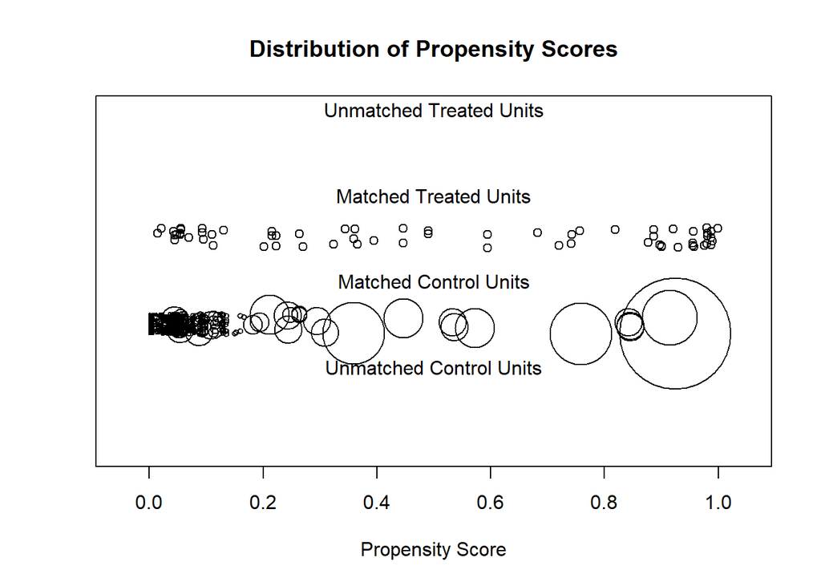

```r
plot(m.out2.1, type = "jitter", interactive = FALSE)
```

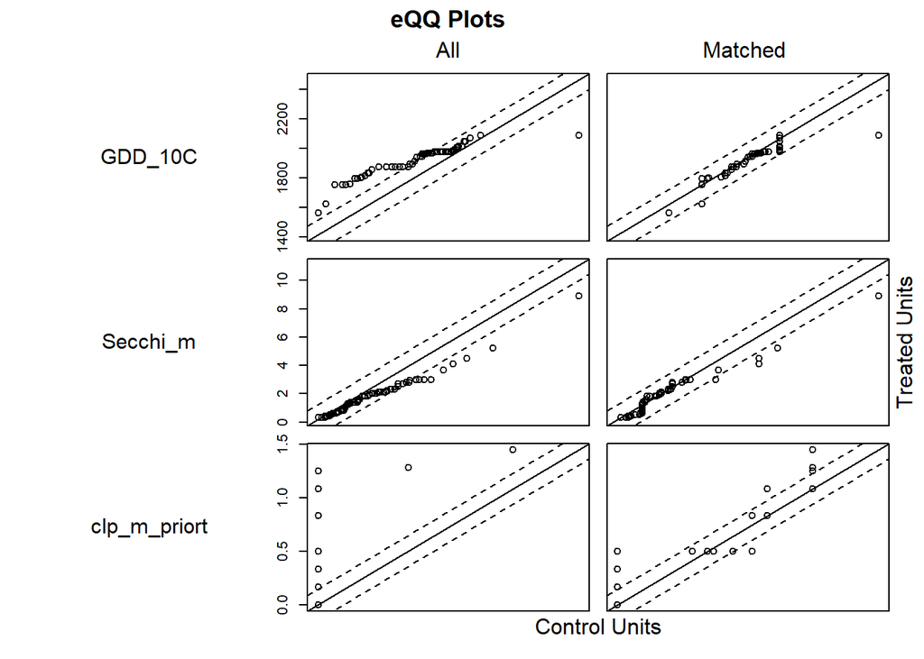

```r
plot(m.out2.1, type = "qq", interactive = FALSE,
     which.xs = c("GDD_10C", "Secchi_m", "clp_m_priort"))
```

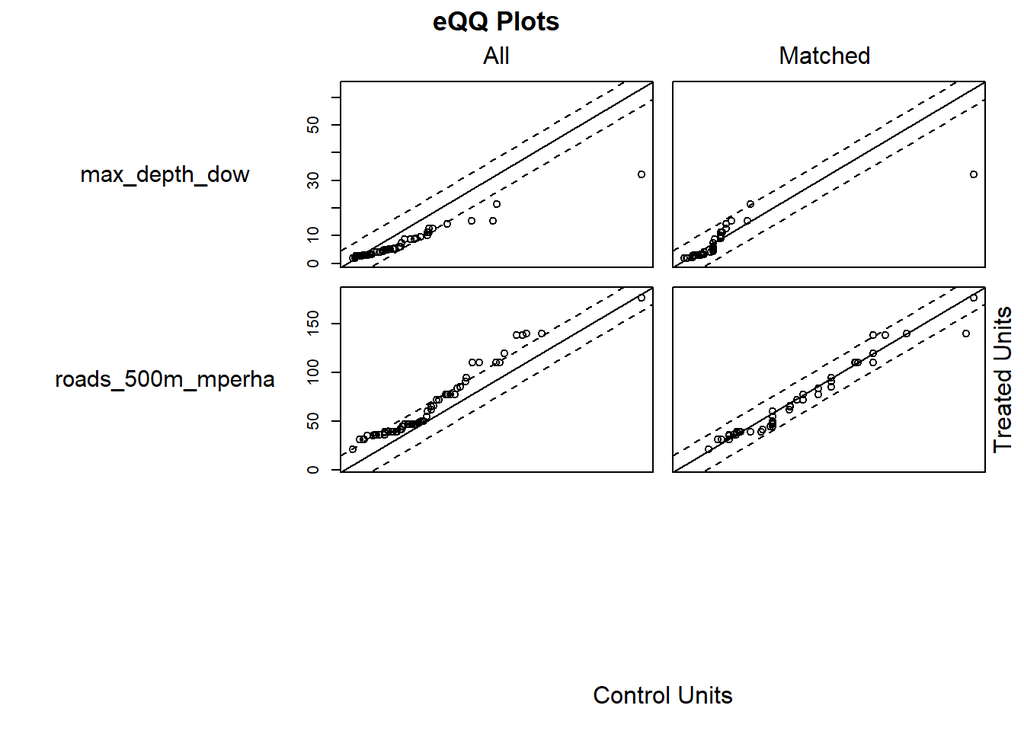

```r
plot(m.out2.1, type = "qq", interactive = FALSE,
     which.xs = c("max_depth_dow", "roads_500m_mperha"))
```